# Environmental filtering drives assembly of diatom communities over evolutionary timescales

Elena Jovanovska<sup>c</sup>, Torsten Hauffe, Björn Stelbrink, Aleksandra Cvetkoska, Zlatko Levkov, Bernd Wagner, Jack H. Lacey, Nadja Ognjanova-Rumenova, Paul B. Hamilton, Christian Albrecht, Karen M. Brandenburg & Thomas Wilke

<sup>c</sup> Corresponding Author: jovanovska.eci@gmail.com

## Abstract

#### Aim

Ecological communities are structured through the interplay of deterministic assembly processes such as competition and environmental filtering. Whereas the drivers of spatial community structure are frequently studied in extant communities, little is known about the relative importance of assembly processes in response to environmental factors over evolutionary timescales. Here, we use an integrative framework to unravel community assembly processes since the inception of a long-lived lake ecosystem.

#### Location

Lake Ohrid.

#### Time period

From lake formation 1.36 million years ago to the present.

#### Major taxa studied

Planktonic diatoms.

#### Methods

We constructed a dated phylogeny of extant and extinct diatoms and collected trait data for 380 fossil communities to quantify phylogenetic community structure and functional richness and to determine the relative importance of deterministic assembly processes over time. We then used regression analysis to correlate the phylogenetic community structure with paleoenvironmental and intrinsic biological predictors and to identify primary drivers of assembly processes.

#### Results

Our results suggest a dense packing of niche space with higher species richness and co-occurrence of closely related species. There are only two short episodes in the very recent past dominated by distantly related taxa. We found distinct changes in phylogenetic community structure upon speciation or extinction events and an increase in mean community relatedness over time.

#### Main conclusions

Our finding of closely related co‑occuring species implies environmental filtering as the primary assembly mechanism, with a minor but increasingly important role of competition towards the present, driven by evolutionary dynamics. Such an increase in the relative contribution of competition to the assembly of communities in relation to the aging of an insular ecosystem, together with a denser packing of morphospace in the early phase of system ontogeny is compatible with ecological predictions according to the theory of island biogeography.

With this html document all steps of the statistical analysis performed in the manuscript are reproduced. It uses parallel computation with up to 28 CPU cores. Adjust Ncores and Threads arguments according to your machine. Computational resources were provided by the de.NBI Cloud within the German Network for Bioinformatics Infrastructure (de.NBI).

### Load packages and custom functions

```r
library(ape)
library(geiger)
library(picante)
library(cluster)
library(FD)
library(ecp)
library(brms)
# install.packages("cmdstanr", repos = c("https://mc-stan.org/r-packages/", getOption("repos")))
library(cmdstanr)
# install_cmdstan(overwrite = TRUE, cores = 1) # Only once to configure
library(spdep)
library(pgirmess)
# library(remotes)
# remotes:::install_github("matthias-da/robCompositions")
library(robCompositions)
library(palinsol)
library(foreach)
library(doParallel)
library(viridis)
library(broom)

source("AuxiliaryFunctions.R")

Comm <- read.table("OhridCyclotellaCommunity.txt", sep = "\t", header = TRUE)
Tree <- read.tree("OhridCyclotella.tree")
Traits <- read.table("OhridCyclotellaTraits.txt", row.names = 1,
                     sep = "\t", header = TRUE, stringsAsFactors = TRUE)
EntireComm <- read.table("OhridEntireCommunity.txt",
                        sep = "\t", header = TRUE, check.names = FALSE)
LR04 <- read.table("LR04_boundaries.txt",
                   sep = "\t", header = TRUE, check.names = FALSE)
Grainsize <- read.table("Grainsize.txt",
                        sep = "\t", header = TRUE, check.names = FALSE)
Pollen <- read.table("Pollen.txt", sep = "\t", header = TRUE)
CaK <- read.table("CaK.txt", sep = "\t", header = TRUE)
Isotope <- read.table("Isotope.txt", sep = "\t", header = TRUE)
TicToc <- read.table("TicToc.txt", sep = "\t", header = TRUE)
Quartz <- read.table("Quartz.txt", sep = "\t", header = TRUE)
LR04Values <- read.table("LR04stack.txt", header = TRUE, skip = 4, sep = "\t")
Gast <- read.table("GAST.txt", header = TRUE, sep = "\t", check.names = FALSE)
Medstack <- read.table("MEDSTACK_Wang2010.txt", sep = "\t", header = TRUE)
```

## 2.2 MPD determination for assembly processes

### 2.2.2 Assessing trait evolution and deterministic assembly processes

### Assessing trait evolution

To infer the relative importance of species competition and environmental filtering, we assessed the phylogenetic structure of diatom communities (i.e. whether closely related species co-occur) and evaluated whether closely related species share similar traits (i.e. a high phylogenetic signal). Trait evolution in *Cyclotella* sensu latu species was assessed via quantifying the phylogenetic signal using Pagel’s $\lambda$ (Pagel, 1999), showing whether the shared phylogenetic history has driven trait distribution of taxa (i.e. $\lambda \approx 1$) and closely related species have similar trait values or whether traits diverge so rapidly that the signal of phylogenetic history is concealed (i.e. $\lambda \approx 0$). Four continuous and nine categorical traits, representing morphological and ecological characteristics of taxonomic and/or functional importance, were scored (Figure 3b, Supporting Information Table S5). Utilizing the Akaike information criterion (AIC) to compare the fit (i.e. $\Delta$AIC) between models of trait evolution with $\lambda$‑transformed branch lengths versus models with untransformed branches provided the statistical support for the phylogenetic signal. Brownian motion models for continuous traits and Markov models with equal transition rates for the categorical traits were fitted using the R package GEIGER 2.0.6 (Harmon et al., 2008).

```r
# Index for the position of the traits in OhridCyclotellaTraits.txt
SeqTraits <- seq(1, 8, by = 2)
# Index for the position of the standard error of the traits in OhridCyclotellaTraits.txt
SeqSe <- seq(2, 8, by = 2)

TreeResolved <- multi2di(Tree) # Resolve polytomies
# Prepare data.frame for saving the results of the tests for phylogenetic signals in
# continuous traits
ContTraits <- as.data.frame(matrix(NA, nr = length(SeqTraits), nc = 7))
rownames(ContTraits) <- colnames(Traits)[SeqTraits]
colnames(ContTraits) <- c("sig2", "loglik", "AIC_BM",
                          "sig2", "Lambda", "loglik", "AIC_Lambda")
# Perform test for phylogenetic signal for all continuous traits
for (i in 1:length(SeqTraits)) {
  X <- Traits[, SeqTraits[i]] # Get trait
  names(X) <- row.names(Traits) # Assign species names to vector of traits
  SE <- Traits[, SeqSe[i]] # Get standard error of the respective trait
  names(SE) <- row.names(Traits)  # Assign species names to vector of standard error
  TreeResolved2 <- TreeResolved
  NaX <- is.na(X) # Are there any species without quantified trait?
  if (any(NaX)) { # If there are any species with missing continuous traits
    # Drop species if no trait form trait values and standard error
    X <- X[-which(NaX)]
    SE <- SE[-which(NaX)]
    # Drop species from tree
    TreeResolved2 <- drop.tip(TreeResolved, names(which(NaX)))
  }
  # Fit Brownian motion model without tree transformation (i.e. phylogenetic signal)
  Fit <- fitContinuous(phy = TreeResolved2, dat = X, SE = SE/sqrt(2),
                       model = "BM")
  # Put model estimates in result table
  ContTraits[i, 1] <- Fit$opt$`sigsq`
  ContTraits[i, 2] <- Fit$opt$lnL
  ContTraits[i, 3] <- Fit$opt$aic
  # Fit Brownian motion model and simultaneously estimate Pagel's Lambda for tree transformation
  # (i.e. lower phylogenetic signal)
  Fit <- fitContinuous(phy = TreeResolved2, dat = X, SE = SE/sqrt(2),
                       model = "lambda")
  # Put model estimates in result table
  ContTraits[i, 4] <- Fit$opt$`sigsq`
  ContTraits[i, 5] <- Fit$opt$lambda
  ContTraits[i, 6] <- Fit$opt$lnL
  ContTraits[i, 7] <- Fit$opt$aic
}
# Calculate support for Lambda transformation over no tree transformation
# Negative AIC suggests Lambda <  1 (decrease in phylogenetic signal)
ContTraits$DeltaAIC <- ContTraits$AIC_BM - ContTraits$AIC_Lambda
ContTraits$Interpretation <- c("WPS", "NPS", "NPS", "NPS")

# Prepare data.frame for saving the results of the tests for phylogenetic signals in
# categorical traits
CatTraits <- as.data.frame(matrix(NA, nrow = 9, ncol = 9))
colnames(CatTraits) <- c("q", "loglik", "AIC_MK",
                         "q", "Lambda", "loglik", "AIC_Lambda",
                         "DeltaAIC", "Interpretation")
rownames(CatTraits) <- colnames(Traits)[9:17]
for (i in 1:9) { # Loop through all categorical traits
  X <- Traits[, 8 + i] # Get categorical trait from table
  names(X) <- row.names(Traits) # Assign species names to vector of categorical traits
  TreeResolved2 <- TreeResolved
  NaX <- is.na(X) # Check for species where we do not know the state of the categorical trait
  if (any(NaX)) { # If there are any species with missing categorical traits
    # Omit species with missing information from vector and phylogeny
    X <- X[-which(NaX)]
    TreeResolved2 <- drop.tip(TreeResolved, names(which(NaX)))
  }
  # As default we use the equal rates model of trait evolution
  # i.e. the transition rates for changes between all states of a categorical trait are
  # equal in all directions A->B = A<-B
  Model <- "ER"
  # 7th categorical trait has ordered states
  # (i.e. transition skipping one level A <-> C not allowed)
  if (i == 7) {
    Model <- "meristic"
  }
  # Fit evolutionary model of state transition
  FitMK <- fitDiscrete(phy = TreeResolved2,
                       dat = X, model = Model)
  # Fit evolutionary model of state transition and simultaneously estimate tree
  # transformation by Pagel's Lambda
  FitLambda <- fitDiscrete(phy = TreeResolved2,
                           dat = X, model = Model,
                           transform = "lambda")
  # Put model estimates in result table
  if (i == 7) {
    Q <- unlist(FitMK$opt[c("q12" , "q23", "q34")])
    CatTraits[i, 1] <- paste(round(Q, 3), collapse = ",")
    Q <- unlist(FitMK$opt[c("q12" , "q23", "q34")])
    CatTraits[i, 4] <- paste(round(Q, 3), collapse = ",")
  }
  else {
    CatTraits[i, 1] <- round(FitMK$opt$`q12`, 3)
    CatTraits[i, 4] <- round(FitLambda$opt$`q12`, 3)
  }
  CatTraits[i, 2] <- FitMK$opt$lnL
  CatTraits[i, 3] <- FitMK$opt$aic
  CatTraits[i, 5] <- FitLambda$opt$lambda
  CatTraits[i, 6] <- FitLambda$opt$lnL
  CatTraits[i, 7] <- FitLambda$opt$aic
}
# Calculate support for Lambda transformation over no tree transformation
# Negative AIC suggests Lambda <  1 (decrease in phylogenetic signal)
CatTraits$DeltaAIC <- CatTraits$AIC_MK - CatTraits$AIC_Lambda
CatTraits$Interpretation <- c("PS", "PS", "PS", "PS", "PS",
                              "WPS", "WPS", "WPS", "WPS")
```

**TABLE 1** Phylogenetic signal in different ecological and morphological traits. Phylogenetic signal (Pagel’s $\lambda$) is the length transformation of phylogenetic branches with $\lambda = 1$ indicating no transformation and that all trait divergence occurs during anagenesis, whereas $\lambda = 0$ points to trait divergence only at speciation events. ΔAIC expresses the difference in fit between models of trait evolution without and with branch length transformation. NPS = no phylogenetic signal, WPS = weak phylogenetic signal, MPS = medium phylogenetic signal, PS = phylogenetic signal.

$\sigma^2$: rate of continuous trait evolution q: transition rate between categorical traits

```r
# print tables in nice looking format via kable()
kable(ContTraits, row.names = TRUE, align = "l",
      digits = c(3, 2, 2, 3, 2, 2, 2, 2, NA))
```

|  | sig2 | loglik | AIC_BM | sig2 | Lambda | loglik | AIC_Lambda | DeltaAIC | Interpretation |
| --- | --- | --- | --- | --- | --- | --- | --- | --- | --- |
| Valve_diameter | 0.023 | -23.43 | 50.87 | 0.004 | 0 | -22.05 | 50.10 | 0.77 | WPS |
| Valve_central_area | 0.063 | -20.32 | 44.65 | 0.005 | 0 | -14.66 | 35.31 | 9.33 | NPS |
| Valve_marginal_area | 0.051 | -22.74 | 49.49 | 0.004 | 0 | -14.30 | 34.60 | 14.89 | NPS |
| Areolae_in_10_mu | 1.860 | -43.85 | 91.70 | 0.064 | 0 | -32.73 | 71.46 | 20.24 | NPS |

```r
kable(CatTraits, row.names = TRUE, align = "l",
      digits = c(NA, 2, 2, NA, 2, 2, 2, 2, NA))
```

|  | q | loglik | AIC_MK | q | Lambda | loglik | AIC_Lambda | DeltaAIC | Interpretation |
| --- | --- | --- | --- | --- | --- | --- | --- | --- | --- |
| Areolae_alveoli_in_central_area | 0.048 | -8.96 | 19.91 | 0.026 | 0.95 | -8.59 | 21.17 | -1.26 | PS |
| Central.fultoportulae | 0.079 | -9.50 | 20.99 | 0.064 | 0.99 | -9.43 | 22.86 | -1.87 | PS |
| Striae_length | 0.008 | -3.99 | 9.97 | 0.008 | 1.00 | -3.99 | 11.97 | -2.00 | PS |
| Undulation_of_central_area | 0.039 | -11.95 | 25.89 | 0.039 | 1.00 | -11.95 | 27.89 | -2.00 | PS |
| Alveoli_structure | 0.017 | -5.37 | 12.73 | 0.017 | 1.00 | -5.37 | 14.73 | -2.00 | PS |
| Lifestyle | 0.005 | -4.17 | 10.33 | 0.002 | 0.00 | -3.44 | 10.88 | -0.55 | WPS |
| Trophic_preferences | 0.998,0.085,10.322 | -15.50 | 37.00 | 0.998,0.085,10.322 | 0.00 | -14.89 | 37.78 | -0.79 | WPS |
| Depressions_papillae | 0.133 | -16.56 | 35.11 | 0.005 | 0.00 | -15.22 | 34.43 | 0.68 | WPS |
| Shape_of_central_area | 0.023 | -18.58 | 39.16 | 0.004 | 0.67 | -16.08 | 36.16 | 3.00 | WPS |

```r
# Reorder from past to present
Comm <- Comm[nrow(Comm):1, ]
# Extant endemics are assumed to be present from first appearance datum until the present
Comm$Cyclotella_bifacialis[Comm$Cyclotella_bifacialis == 0 & Comm$Age > -621.20705] <- 1
Comm$Cyclotella_fottii[Comm$Cyclotella_fottii == 0] <- 1
Comm$Lindavia_thienemannii[Comm$Lindavia_thienemannii == 0 & Comm$Age > -122.93015] <- 1

# Endemic species but today absent i.e. endemic fossils
EndAbs <- c("Cribrionella_ohridana", "Cyclotella_cavitata", "Cyclotella_sollevata",
            "Pantocsekiella_multiocellata", "Pantocsekiella_preocellata")
for(i in 1:length(EndAbs)){
  Tmp <- Comm[, EndAbs[i]] # Get vector of species abundancies
  R <- range(which(Tmp > 0)) # Get range of the species
  Tmp[ which(Tmp[R[1]:R[2]] == 0) + R[1]-1 ] <- 1 # Present from first to last appearance datum
  Comm[, EndAbs[i]] <- Tmp # Assign again to table with abundancies
}
```

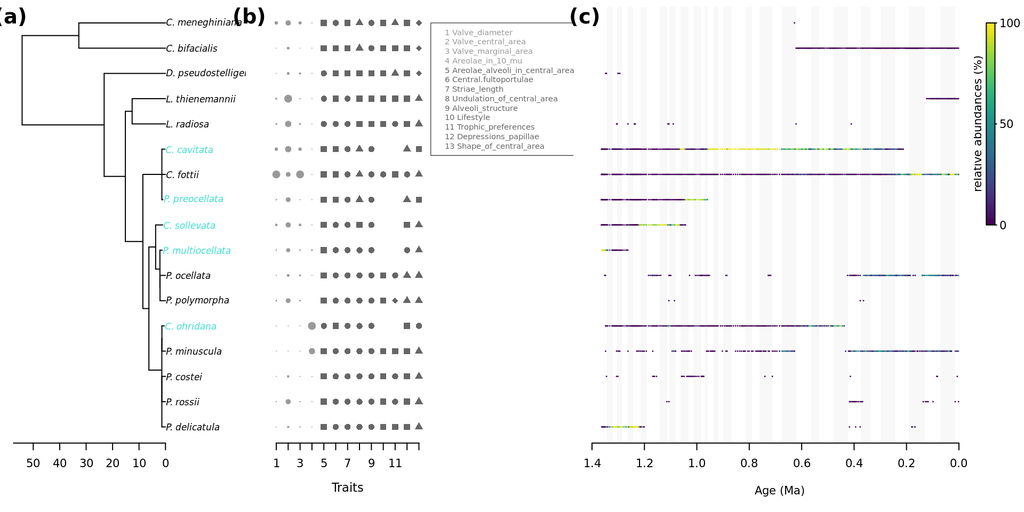

```r
TreeTmp <- Tree
# Different color for endemics (turquoise) and non-endemics (black)
TipColor <- rep("black", 17)
TipColor[Tree$tip.label %in% c("Cyclotella_cavitata",
                               "Pantocsekiella_multiocellata",
                               "Cyclotella_sollevata",
                               "Pantocsekiella_preocellata",
                               "Cribrionella_ohridana")] <- "turquoise"
# Abbreviate genus names
TipLabels <- strsplit(Tree$tip.label, "_")
TreeTmp$tip.label <- unlist(lapply(TipLabels,
                                   function(x) paste0(substring(x[1], 1, 1), "._", x[2])))
# Order traits of species according to the plot-order of the phylogeny
TraitsPlot <- Traits[pmatch(Tree$tip.label, row.names(Traits)), ]

# Four panel plot
layout(matrix(1:4, nrow = 1, ncol = 4), widths = c(0.24, 0.32, 0.39, 0.05))
# Plot phylogeny
par(las = 1, mar = c(5.1, 1, 0.5, 0), lwd = 0.5)
plot(TreeTmp, show.tip.label = TRUE, cex = 0.8,
     tip.color = TipColor)
axisPhylo()
mtext(text = "(a)", side = 2, line = -1,
      at = par("usr")[4] - diff(par("usr")[3:4]) * 0.02,
      font = 2, cex = 1.2)
# Plot traits along the tips of the phylogeny
par(las = 1, mar = c(5.1, 0.5, 0.5, 0), lwd = 0.5)
plot(1, 1, type = "n", xlim = c(0, 25), ylim = c(1, 17),
     axes = FALSE, xlab = "", ylab = "")
axis(side = 1, at = 1:13)
mtext(text = "Traits", side = 1, line = 2.8, at = 7, cex = 0.7)
mtext(text = "(b)", side = 2, line = -1,
      at = par("usr")[4] - diff(par("usr")[3:4]) * 0.02,
      font = 2, cex = 1.2)
CexPoints <- 1.2
for (i in 1:4) { # Continuous traits
  # Standardize continuous trait in range [0,1]
  StandTrait <- (TraitsPlot[, SeqTraits[i]] - min(TraitsPlot[, SeqTraits[i]], na.rm = TRUE)) /
    (max(TraitsPlot[, SeqTraits[i]], na.rm = TRUE) - min(TraitsPlot[, SeqTraits[i]], na.rm = TRUE))
  points(rep(i, 17),
         1:17, pch = 19,
         cex = CexPoints * (0.1 + StandTrait)^2, col = "grey60")
}
for (i in 1:9) { # Categorical traits
  points(rep(4 + i, 17),
         1:17, pch = as.numeric(as.factor(TraitsPlot[, 8 + i])) + 14,
         cex = CexPoints, col = "grey40")
}
legend(x = 14, y = 17,
       legend = paste(1:13, colnames(TraitsPlot)[-c(SeqSe)]),
       cex = 0.7, text.col = c(rep("grey60", 4), rep("grey40", 9)))
# Plot abundancies over time; align with tips of the phylogenies
par(las = 1, mar = c(5.1, 1, 0.5, 0), lwd = 0.5)
IsTip <- Tree$edge[, 2] <= length(Tree$tip.label)
OrderedTips <- Tree$edge[IsTip, 2]
ColGrad <- viridis(100) # Define color gradient to display relative abundances
plot(1, 1, xlim = range(Comm$Age), ylim = c(0, 1),
     type = "n", bty = "n", xaxt = "n", yaxt = "n",
     ylab = "", xlab = "Age (Ma)") # Empty canvas
mtext(text = "(c)", side = 2, line = -1,
      at = par("usr")[4] - diff(par("usr")[3:4]) * 0.02,
      font = 2, cex = 1.2)
for(i in 1:nrow(LR04)){ # Plot glacial/interglacials
  if( -LR04[i,2] > min(Comm$Age) & (LR04[i,1] %% 2 == 1) ){
    rect(xleft = -LR04[i,2], ybottom = par("usr")[3],
         xright = -LR04[i-1,2], ytop = par("usr")[4],
         border = NA, col = adjustcolor("grey", alpha.f = 0.1))
  }
}
Div <- rowSums(Comm[, -c(1:3)]) # Get total number of diatom specimens per assemblage
Seq <- seq(0, 1, length.out = 100)
Y <- seq(0, 1, length.out = 17) # Height on y-axis for all 17 species
for (i in 1:(ncol(Comm)-3)) { # For all species
  Sp <- Comm[, Tree$tip.label[OrderedTips][i]] # Get abundances of focal species
  Sp <- Sp/Div # Convert absolute to relative abundance
  W <- which(Sp > 0) # At which time do we find the species?
  ColTmp <- ColGrad[sapply(Sp, function(x) sum( Seq < x) )] # Get color for abundances
  points(x = Comm$Age[W], y = rep(Y[i], length(W)),
         pch = 19, cex = 0.2, col = ColTmp)
}
axis(side = 1, at = seq(-1400, 0, 200),
     labels = rev(c("0.0", "0.2", "0.4", "0.6", "0.8", "1.0", "1.2", "1.4")))
# Add legend for relative abundances
par(mar = c(5.1, 0.1, 0.5, 0.1))
plot(1, 1, type = "n", axes = FALSE, xlab = "", ylab = "", xlim = c(-0.2, 5),
     ylim = c(-100, 100))
rasterImage(as.raster( matrix(rev(ColGrad), nrow = length(ColGrad), ncol = 1) ),
            xleft = 1, xright = 2, ybottom = 0, ytop = 100,
            interpolate = FALSE)
text(x = 0, y = 50, labels = "relative abundances (%)", srt = 90)
rect(xleft = 1, xright = 2, ybottom = 0, ytop = 100, lwd = 1)
segments(x0 = 2, y0 = 0, x1 = 2.2, y1 = 0, lwd = 1)
text(x = 2.5, y = 0, labels = "0", adj = 0)
segments(x0 = 2, y0 = 50, x1 = 2.2, y1 = 50, lwd = 1)
text(x = 2.5, y = 50, labels = "50", adj = 0)
segments(x0 = 2, y0 = 100, x1 = 2.2, y1 = 100, lwd = 1)
text(x = 2.5, y = 100, labels = "100", adj = 0)
```

**FIGURE 3** Trait evolution and abundancies of Lake Ohrid *Cyclotella* sensu lato species over time. (a) Dated phylogeny including extinct endemic species from Lake Ohrid (for details see Figure 1). (b) Light-grey symbols show trait expression with circle size proportional to the values of continuous traits and dark-grey symbols (i.e. triangle, square, and circle) the states of categorical traits. (c) Colored dots represent relative abundances of *Cyclotella* s.l. species found in DEEP-5045-1 sediment record; vertical grey and white bars indicate glacial and interglacial periods, respectively.

### Assessing deterministic assembly processes

The phylogenetic structure for each of the 380 diatom communities sampled at different time points in the past was quantified by calculating the MPD between species of a community along the dated phylogeny. A null model of random phylogenetic community structure assuming even species richness was compared to the observed communities to quantify the standard effect size (SES) of the observed MPD. This measure evaluates whether a species community is a result of phylogenetic clustering (values < 0) or overdispersion (values > 0), reflecting the presence of either more closely or more distantly related species within the community than expected by the null model. For each time point, the null model involves shuffling of species identities 999 times across the tips of the phylogeny with probabilities proportional to their abundances in the previous time step. Standard null models of shuffling abundances in the community matrix may not be appropriate here, because they do not yet consider the time structure of the data. Branch lengths were pruned to the age of the assemblage and the pairwise phylogenetic distance was weighted by the relative abundance of the respective species pair. The MPD was quantified with the R package ‘picante’ 1.6.2 (Kembel et al., 2010).

```r
# Pairwise phylogenetic distances between species (i.e. sum of branch length separating them)
CophTree <- cophenetic(Tree)
# Get standardized effect size of the mean phylogenetic distance of every assemblage
SesMpd <- getSesMpd(Comm, # Observed diatom assemblages
                    CophTree, # Observed pairwise phylogenetic distances
                    Runs = 999, # 999x MPD according to a Null model of community assembly
                    Ncores = 28) # Generate Null communities in parallel on 28 cores
```

## 2.3 Assessing morphospace occupation patterns

To test whether niche space expands in a given assemblage and is more packed with higher species richness, we estimated functional richness over time and the correlation between functional richness and species richness. We quantified the functional richness index FRic (Villéger et al., 2008) based on all 13 traits for the same 380 communities, using the R package FD 1.0-12 (Laliberté et al., 2014). The actual values of FRic were compared to a null model of a random expectation, resulting in the standardized effect size (SES.FRic), which allowed us to determine whether the phylogenetic community structure and species richness was associated to small (< 0) or large (> 0) occupancy of niche space.

```r
TraitsScaled <- data.frame(scale(Traits[, SeqTraits]), # Scale four continuous traits
                           Traits[, 9:17]) # Nine discrete traits
# Get standardized effect size of the functional richness  of every assemblage
SesFric <- getSesFric(Comm[, -c(1:3)], # Observed diatom assemblages; without vial, depth and age
                      TraitsScaled, #
                      Runs = 999,  # 999x functional richness according to a Null model of community assembly
                      Ncores = 28) # Generate Null communities in parallel on 28 cores
```

To evaluate the effect of taxon sampling on the species richness trajectory, we performed a rarefaction analysis. We randomly sampled 100 individuals from the entire diatom assemblage at a moment in time (extracted from Wilke et al. 2020), determined the number of *Cyclotella* s.l. species and repeated the random subsampling 1000 times to calculate the mean richness and its variability over time.

```r
TotalCounts <- rowSums(EntireComm) # Get number of individuals per sediment sample
Size <- 100 # Minimum of 100 Cyclotella individuals in the observed assemblage
# Do stochastic rarefaction. The function returns a list with two elements:
# [[1]] A matrix of rarefied species richness with richness through time in rows and
#       columns giving the mean richness and 2.5 and 97.5 percentiles
# [[2]] A list with all 1000 rarefied assemblages, which we will use in the next code chunk to
#       calculate the functional richness, MPD and the correlation between functional richness
#       and rarefied species richness
StochRarefied <- stochasticRarefaction(# Use only those sediment samples
                                       # of the entire diatom assemblage (i.e. incl additional genera than just Cyclotella)
                                       # where we have at least 100 Cyclotella individuals
                                       EntireComm = EntireComm[TotalCounts > Size, ],
                                       Size = Size, # Minimum of 100 Cyclotella individuals
                                       Reps = 1000, # Repeat subsampling 1000 times
                                       # Get all names of Cyclotella species to subset the EntireComm
                                       # from the column names of the Cyclotella community matrix.
                                       # Remove names of vials, age and depth
                                       Planktonics = colnames(Comm)[-c(1:3)],
                                       EndThrough = TRUE, # Range through occurrence of endemics
                                       Ncores = 28) # Do 1000x subsampling on 28 cores in parallel
```

```r
Rep <- 100 # 100x i.e. use 100 of the 1000 rarefied assemblages
FricSrRar <- rep(NA_real_, Rep) # Empty vector to store the correlation between rarefied functional and species richness
# Empty matrices to store MPD and functional richness for rarefied assemblages.
# They will be used for the shaded areas in Figure 4
SesMpdRarMat <- SesFricRarMat <- matrix(NA_real_, ncol = Rep, nrow = nrow(Comm))
for (i in 1:Rep) {
  # SES functional richness for rarefied assemblages
  SesFricRar <- getSesFric(StochRarefied[[2]][[i]], # Take the i-th assemblage from 1-100
                           TraitsScaled, # Traits centered and scaled to unit variance
                           Runs = 99, # 99 permutations to generate Null communities
                           Ncores = 28) # Do on 28 cores in parallel
  # We only have functional richness for assemblages with more than 100 observed individuals
  # because with lower counts the rarified assemblages are very stochastic
  SesFricRarMat[TotalCounts > Size, i] <- SesFricRar
  # Correlation between species richness and functional richness
  # Convert rarefied abundancies to species richness
  SrRar <- rowSums(ifelse(StochRarefied[[2]][[i]] > 0, 1, 0))
  # Slope coefficient for relationship functional/species richness
  FricSrRar[i] <- coef(lm(SesFricRar ~ SrRar))[2]
  # Create same format for the rarefied community matrix as we have for our observed assemblages
  RareComm <- data.frame(Comm[TotalCounts > Size, 1:3], # Ages/sample indices for assemblages with more than 100 individuals
                         StochRarefied[[2]][[i]])  # Take the i-th assemblage from 1-100
  # SES phylogenetic community structure for rarefied assemblages
  SesMpdRar <- getSesMpd(RareComm, # Rarefied assemblages
                         CophTree, # Pairwise phylogenetic distance between species
                         Runs = 99,  # 99 permutations to generate Null communities
                         Ncores = 28) # Do on 28 cores in parallel
  # We only have SES MPD for assemblages with more than 100 observed individuals
  # because with lower counts the rarified assemblages are very stochastic
  SesMpdRarMat[TotalCounts > Size, i] <- SesMpdRar
}
# 95% range of SES functional richness for rarefied assemblages
SesFricCI <- apply(SesFricRarMat, 1, function(x) quantile(x, c(0.025, 0.975), na.rm = TRUE))
SesFricCI <- rbind(Comm$Age, SesFricCI) # Bind age to the 95% range
SesFricCI <- SesFricCI[, !is.na(SesFricCI[2, ])] # Omit parts where there are less than 100 individuals in assemblage
# 95% range of SES MPD for rarefied assemblages
SesMpdCI <- apply(SesMpdRarMat, 1, function(x) quantile(x, c(0.025, 0.975), na.rm = TRUE))
SesMpdCI <- rbind(Comm$Age, SesMpdCI) # Bind age to the 95% range
SesMpdCI <- SesMpdCI[, !is.na(SesMpdCI[2, ])] # Omit parts where there are less than 100 individuals in assemblage
```

```r
Sr <- rowSums(ifelse(Comm[, -c(1:3)] > 0, 1, 0)) # Species richness of the cyclotella assemblages
# Linear regression model for the relationship between SES Functional richness (response) and species richness (predictor)
FricSrLM <- lm(SesFric ~ Sr)

# Display regression result in nice table for the html document
kable(tidy(FricSrLM))
```

| term | estimate | std.error | statistic | p.value |
| --- | --- | --- | --- | --- |
| (Intercept) | 1.1314426 | 0.1505631 | 7.514739 | 0 |
| Sr | -0.2554858 | 0.0289414 | -8.827687 | 0 |

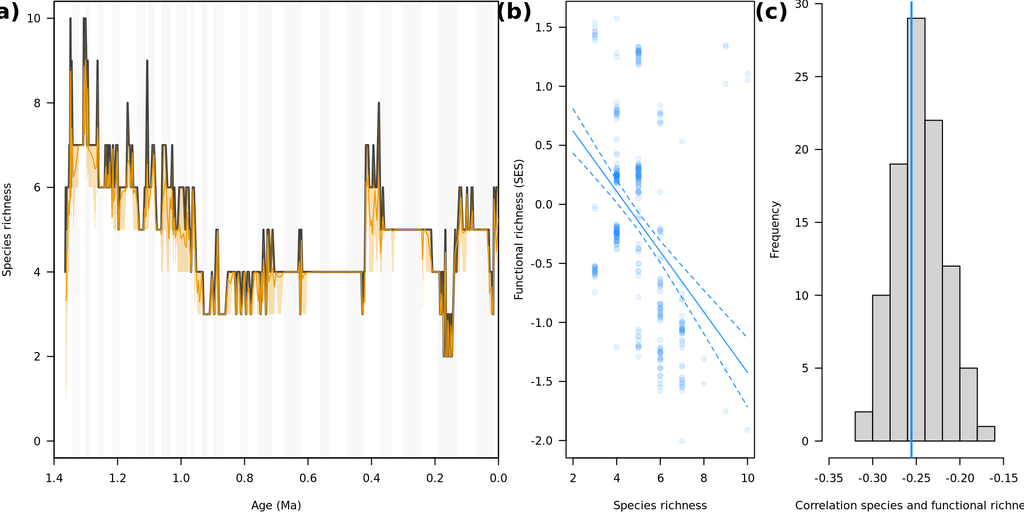

```r
# Predict functional richness for species richness from 2 to 10
PredFr <- predict(FricSrLM, # Use the linear regression model
                  newdata = data.frame(Sr = 2:10), # Species richness 2-10
                  se.fit = TRUE) # get confidence interval of the mean prediction

# Create plot with three panels
layout(matrix(1:3, ncol = 3), widths = c(0.5, 0.25, 0.25))
par(las = 1, mar = c(4, 4, 0.1, 1)) # Set orientation of label on x-axis and margins
plot(1, 1, type = "n", xaxs = "i",
     xlab = "Age (Ma)", ylab = "Species richness",
     xaxt = "n", xlim = c(-1400, 0), ylim = c(0, 10))
axis(side = 1, at = seq(-1400, 0, 200),
     labels = rev(c("0.0", "0.2", "0.4", "0.6", "0.8", "1.0", "1.2", "1.4")))
mtext(text = "(a)", side = 2, line = 2.5,
      at = par("usr")[4] - diff(par("usr")[3:4]) * 0.02, font = 2, cex = 1.3)
plotLR04(LR04, Comm$Age) # Add grey rectangles showing glacial/interglacials
box()
lines(Comm$Age, Sr, col = "grey25", lwd = 2)
polygon(c(Comm$Age[TotalCounts > Size], rev(Comm$Age[TotalCounts > Size])),
        c(StochRarefied[[1]][2, ], rev(StochRarefied[[1]][3, ])),
        border = NA,
        col = adjustcolor("orange2", 0.3))
lines(Comm$Age[TotalCounts > Size], StochRarefied[[1]][1, ],
      col = "orange2")

plot(SesFric ~ Sr, xlab = "Species richness", ylab = "Functional richness (SES)",
     pch = 19, col = adjustcolor("dodgerblue", 0.1))
mtext(text = "(b)", side = 2, line = 2.5,
      at = par("usr")[4] - diff(par("usr")[3:4]) * 0.02, font = 2, cex = 1.3)
lines(2:10, PredFr$fit, col = "dodgerblue")
lines(2:10, PredFr$fit + 1.96*PredFr$se.fit, col = "dodgerblue", lty = 2)
lines(2:10, PredFr$fit - 1.96*PredFr$se.fit, col = "dodgerblue", lty = 2)

hist(FricSrRar, xlim = c(-0.35, -0.15), main = "",
     xlab = "Correlation species and functional richness")
abline(v = coef(FricSrLM), col = "dodgerblue", lwd = 2)
mtext(text = "(c)", side = 2, line = 2.5,
      at = par("usr")[4] - diff(par("usr")[3:4]) * 0.02, font = 2, cex = 1.3)
```

## 2.4 Local paleoenvironmental, climatic, and intrinsic biological effects on phylogenetic community structure

### 2.4.1 Local paleoenvironmental predictors

We derived the following local paleoenvironmental predictors from the sediment record: total inorganic carbon (TIC), total organic carbon (TOC), potassium (K) counts from XRF scanning, relative sedimentary quartz content, percentages of arboreal pollen excluding Pinus pollen, percentage of pollen from deciduous oaks (Wagner et al., 2019), oxygen isotope composition of the lake water ($\delta^{18}$O<sub>lakewater</sub>), and grain size (Wilke et al., 2020). In order to reduce the noise of these predictors in the regression analysis, we used Gaussian process smoothing, suggested by Simpson (2018) for sediment records. We used the implementation in the R package ‘brms’ 2.15.0 (Bürkner, 2018), which itself is an interface to the Bayesian inference machinery of stan 2.21 (Stan Development Team, 2021).

#### Aboreal pollen and oaks

For the Gaussian process smoothing of the relative abundance of aboreal pollen and oaks, we used a binomial distribution for the percentage of specific taxa from the total pollen count. To account for variations in sedimentation rate, we assigned weights to each sample of the paleoenviromental predictor representing time captured by the sample (Simpson, 2018). All smoothing models were inferred through Hamiltonian Monte Carlo sampling with four parallel chains (details in Table S6). Through this process we achieved the same temporal resolution for fossil and local paleoenvironmental data. We then matched paleoenvironmental predictors with MPD via their age.

```r
Pollen <- Pollen[nrow(Pollen):1, ] # Order from past (top) to the present (bottom)
Pollen$Weight <- getWeight(Pollen$Age) # Get observational weights

# Specify prior
PriorAP <- c(prior(normal(0, 1), class = Intercept),
             prior(inv_gamma(1.494197, 0.056607), class = lscale, coef = "gpAge"),
             prior(normal(0, 2), class = sdgp))
Nchains <- 4 # Run four chains
Ncores <- 4 # On four cores in parallel
# Additional three cores for within-chain parallelization to speed-up inference
# (i.e. 4x3 cores per chain)
Threads <- 3
Sys.setenv(STAN_NUM_THREADS = Threads)
# Get initial values from where we start Hamiltonian Monte Carlo sampling
Inits <- setInitsPollen(Seed = sample(73, Nchains), # Random seed
                        Length = Nchains, # Four sets of intial values for the four chains
                        K = 400) # Basis of 400 for approximate Gaussian processes

# Response:
#   AP | trials(Total): Number of aboreal pollen (AP) in comparison to the total count of pollen ( |trials(Total) ),
#                       which gives us the proportion of aboreal pollen
#   + weights(Weight): Observational weights per pollen sample (time captured by each sample);
#                      accounts for heteroskedasticity (Simpson, 2018)
# Predictor:
# ~ gp(Age, k = 400, c = 5/4, gr = FALSE): Gaussian process smoothing of age of the pollen sample
BrmAP <- brm(AP | trials(Total) + weights(Weight) ~ gp(Age, k = 400, c = 5/4, gr = FALSE),
             data = Pollen,
             family = binomial(), # Binomial distribution because we have a proportion of pollen
             inits = Inits, # Use initial values obtained by setInitsPollen()
             chains = Nchains, # Number of chains
             cores = Ncores, # Number of cores
             prior = PriorAP, # Prior
             iter = 2000, # 2000 iterations in total
             warmup = 1000, # 1000 warm-up iterations
             thin = 1, # Keep every sample
             refresh = 0, # Do not print progress in the markdown document
             # Within chain parallelization only available in cmdstanr and not default rstan
             threads = threading(Threads),
             backend = "cmdstanr",
             # Control stan sample
             # * adapt_delta: target for the average of proposal acceptance probability
             #                during the warm-up period, higher value causes smaller steps
             # * max_treedepth: depth of the trees that is evaluated during each iteration
             #                  increases efficiency (less iterations, but each iteration lasts longer)
             control = list(adapt_delta = 0.9, max_treedepth = 20))
```

```
## Running MCMC with 4 parallel chains, with 3 thread(s) per chain...
##
## Chain 3 finished in 408.7 seconds.
## Chain 2 finished in 414.4 seconds.
## Chain 1 finished in 415.2 seconds.
## Chain 4 finished in 427.3 seconds.
##
## All 4 chains finished successfully.
## Mean chain execution time: 416.4 seconds.
## Total execution time: 427.8 seconds.
```

```r
# Summarize posterior distribution of parameters and evaluate convergence through Rhat and ESS
summary(BrmAP)
```

```
##  Family: binomial
##   Links: mu = logit
## Formula: AP | trials(Total) + weights(Weight) ~ gp(Age, k = 400, c = 5/4, gr = FALSE)
##    Data: Pollen (Number of observations: 697)
##   Draws: 4 chains, each with iter = 1000; warmup = 0; thin = 1;
##          total post-warmup draws = 4000
##
## Gaussian Process Terms:
##               Estimate Est.Error l-95% CI u-95% CI Rhat Bulk_ESS Tail_ESS
## sdgp(gpAge)       1.72      0.14     1.47     2.00 1.01     1130     2010
## lscale(gpAge)     0.00      0.00     0.00     0.00 1.00     3959     3435
##
## Population-Level Effects:
##           Estimate Est.Error l-95% CI u-95% CI Rhat Bulk_ESS Tail_ESS
## Intercept     0.13      0.14    -0.15     0.40 1.00     4315     2693
##
## Draws were sampled using sample(hmc). For each parameter, Bulk_ESS
## and Tail_ESS are effective sample size measures, and Rhat is the potential
## scale reduction factor on split chains (at convergence, Rhat = 1).
```

```r
# Get smoothed values of aboreal pollen proportion for the same moments in time where we have a diatom assemblage.
# Will be used as a potential predictor of mean phylogenetic community distance (MPD)
# in the regression analysis (FitMPD)
NewData <- data.frame(Age = Comm$Age,
                      Total = 100) # Total of 100 pollen, i.e. we get the percantage of aboreal pollen
PredAP <- predict(BrmAP, newdata = NewData)
```

Residuals were tested for autocorrelation using the Moran’s I index for irregularly-spaced time series (see Legendre & Gauthier, 2014).

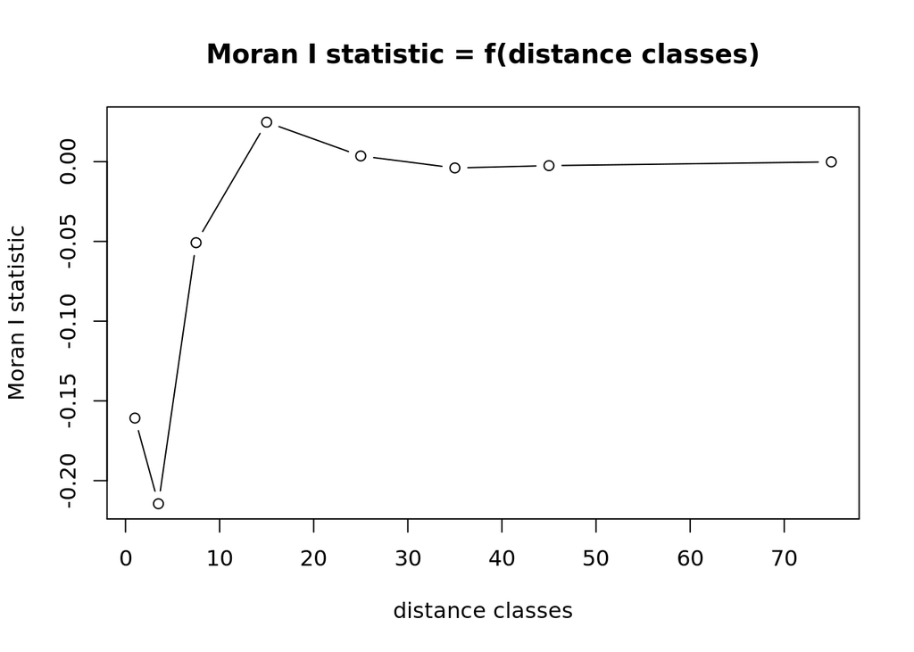

```r
# Check for remaining temporal autocorrelation, which could indicate a bias in
# inferred parameters
ResidAP <- residuals(BrmAP, method = "posterior_predict") # Get residuals
# Define bins for which the autocorrelation should be calculated
Breaks <- rbind(c(0.001, 2), # From 0 to 2,000 years (between one and the next diatom sample)
                c(2, 5),     # 2,000 to 5,000 years
                c(5, 10),    # 5,000 to 10,000 years
                c(10, 20),   # 10,000 to 20,000 years
                c(20, 30),   # 20,000 to 30,000 years
                c(30, 40),   # 30,000 to 40,000 years (similar to 40,000 year cycle of Milankovitch)
                c(40, 50),   # 40,000 to 50,000 years
                c(50, 100))  # 50,000 to 100,000 years (similar to 100,000 year cycle of Milankovitch)
MoranAP <- correlogFork(time = Pollen$Age[!is.na(Pollen$AP)], # Time where we have pollen observations
                        z = ResidAP[, 1], # Use the mean residual from the posterior
                        method = "Moran", # Use Moran's I
                        breaks = Breaks)
plot(MoranAP) # Red dot indicates significant autocorrelation
```

```r
PriorOaks <- c(prior(normal(0, 1), class = Intercept),
             prior(inv_gamma(1.494197, 0.056607), class = lscale, coef = "gpAge"),
             prior(normal(0, 2), class = sdgp))
Nchains <- 4
Ncores <- 4
Inits <- setInitsPollen(Seed = sample(73, Nchains), Length = Nchains, K = 400)
Threads <- 3
Sys.setenv(STAN_NUM_THREADS = Threads)
BrmOaks <- brm(DecOaks | trials(Total) + weights(Weight) ~ gp(Age, k = 400, c = 5/4, gr = FALSE),
               data = Pollen,
               family = binomial(),
               inits = Inits,
               chains = Nchains, cores = Ncores,
               prior = PriorAP,
               iter = 2000, warmup = 1000, thin = 1, refresh = 0,
               threads = threading(Threads), backend = "cmdstanr",
               control = list(adapt_delta = 0.9, max_treedepth = 20))
```

```
## Running MCMC with 4 parallel chains, with 3 thread(s) per chain...
##
## Chain 1 finished in 370.3 seconds.
## Chain 2 finished in 377.4 seconds.
## Chain 4 finished in 382.1 seconds.
## Chain 3 finished in 383.0 seconds.
##
## All 4 chains finished successfully.
## Mean chain execution time: 378.2 seconds.
## Total execution time: 383.5 seconds.
```

```r
summary(BrmOaks)
```

```
##  Family: binomial
##   Links: mu = logit
## Formula: DecOaks | trials(Total) + weights(Weight) ~ gp(Age, k = 400, c = 5/4, gr = FALSE)
##    Data: Pollen (Number of observations: 696)
##   Draws: 4 chains, each with iter = 1000; warmup = 0; thin = 1;
##          total post-warmup draws = 4000
##
## Gaussian Process Terms:
##               Estimate Est.Error l-95% CI u-95% CI Rhat Bulk_ESS Tail_ESS
## sdgp(gpAge)       1.29      0.13     1.07     1.60 1.01      862     1769
## lscale(gpAge)     0.00      0.00     0.00     0.00 1.00     2172     3012
##
## Population-Level Effects:
##           Estimate Est.Error l-95% CI u-95% CI Rhat Bulk_ESS Tail_ESS
## Intercept    -1.45      0.11    -1.66    -1.23 1.00     8965     3006
##
## Draws were sampled using sample(hmc). For each parameter, Bulk_ESS
## and Tail_ESS are effective sample size measures, and Rhat is the potential
## scale reduction factor on split chains (at convergence, Rhat = 1).
```

```r
PredOaks <- predict(BrmOaks, newdata = NewData)
```

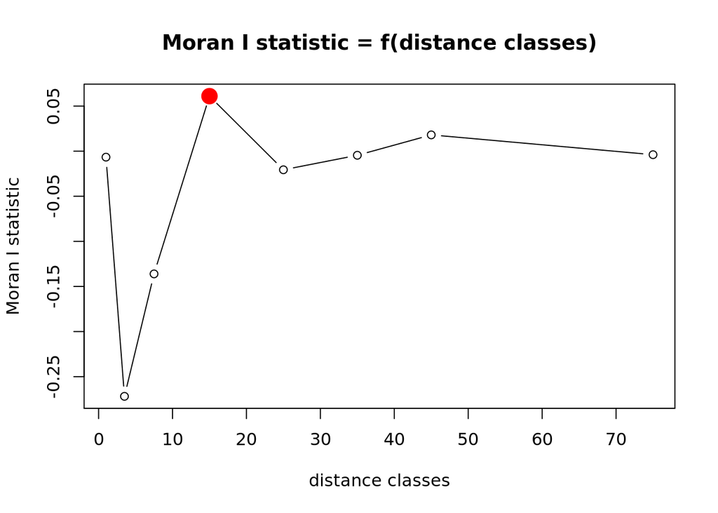

```r
ResidOaks <- residuals(BrmOaks, method = "posterior_predict")
MoranOaks <- correlogFork(time = Pollen$Age[!is.na(Pollen$DecOaks)],
                          z = ResidOaks[, 1], method = "Moran", breaks = Breaks)
plot(MoranOaks)
```

#### Quartz, TIC and TOC

For the Gaussian process smoothing of quartz, TIC, and TOC, we used a beta distribution for quartz, TIC, and TOC because they were quantified as the relative quartz content or the share from a given mass of sediment sample.

```r
Quartz <- Quartz[nrow(Quartz):1, ]
Quartz$Weight <- getWeight(Quartz$Age)
Nchains <- 4
Ncores <- 4
Inits <- setInitsQuartz(Seed = sample(73, Nchains), Length = Nchains, K = 1000)
Threads <- 3
Sys.setenv(STAN_NUM_THREADS = Threads)
BrmQuartz <- brm(Quartz | weights(Weight) ~ gp(Age, k = 1000, c = 5/4),
                 # Beta-distribution for proportions without knowing the denominator
                 # (i.e. the total area )
                 family = Beta(),
                 data = Quartz,
                 inits = Inits,
                 cores = Ncores, chains = Nchains,
                 iter = 3000, warmup = 1000, thin = 1, refresh = 0,
                 threads = threading(Threads), backend = "cmdstanr",
                 control = list(adapt_delta = 0.9, max_treedepth = 10))
```

```
## Running MCMC with 4 parallel chains, with 3 thread(s) per chain...
##
## Chain 3 finished in 687.3 seconds.
## Chain 4 finished in 703.5 seconds.
## Chain 1 finished in 727.2 seconds.
## Chain 2 finished in 747.3 seconds.
##
## All 4 chains finished successfully.
## Mean chain execution time: 716.3 seconds.
## Total execution time: 748.2 seconds.
```

```r
summary(BrmQuartz)
```

```
##  Family: beta
##   Links: mu = logit; phi = identity
## Formula: Quartz | weights(Weight) ~ gp(Age, k = 1000, c = 5/4)
##    Data: Quartz (Number of observations: 1462)
##   Draws: 4 chains, each with iter = 2000; warmup = 0; thin = 1;
##          total post-warmup draws = 8000
##
## Gaussian Process Terms:
##               Estimate Est.Error l-95% CI u-95% CI Rhat Bulk_ESS Tail_ESS
## sdgp(gpAge)       0.49      0.02     0.45     0.54 1.00     3597     5382
## lscale(gpAge)     0.00      0.00     0.00     0.00 1.00      501     1541
##
## Population-Level Effects:
##           Estimate Est.Error l-95% CI u-95% CI Rhat Bulk_ESS Tail_ESS
## Intercept    -1.28      0.04    -1.37    -1.20 1.00    11088     6259
##
## Family Specific Parameters:
##     Estimate Est.Error l-95% CI u-95% CI Rhat Bulk_ESS Tail_ESS
## phi   184.31     10.91   164.36   206.62 1.00      826     2833
##
## Draws were sampled using sample(hmc). For each parameter, Bulk_ESS
## and Tail_ESS are effective sample size measures, and Rhat is the potential
## scale reduction factor on split chains (at convergence, Rhat = 1).
```

```r
PredQuartz <- predict(BrmQuartz, newdata = NewData)
```

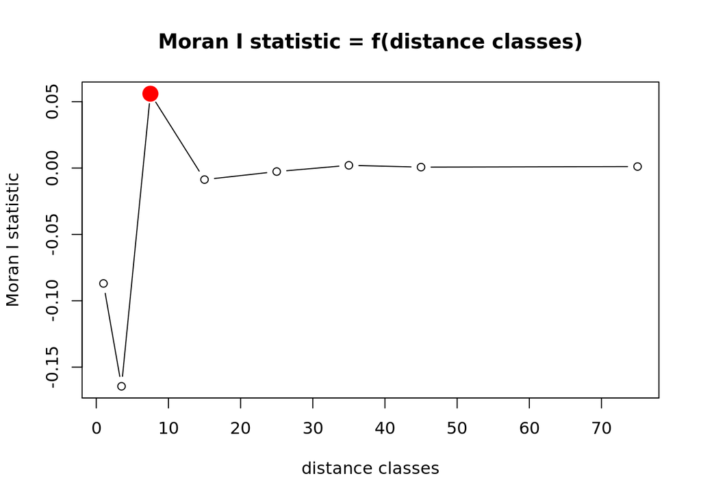

```r
ResidQuartz <- residuals(BrmQuartz, method = "posterior_predict")
MoranQuartz <- correlogFork(time = Quartz$Age[!is.na(Quartz$Quartz)],
                            z = ResidQuartz[, 1], method = "Moran", breaks = Breaks)
plot(MoranQuartz)
```

```r
TicToc <- TicToc[nrow(TicToc ):1, ]
TicToc$Weight <- getWeight(TicToc$Age)

Threads <- 3
Sys.setenv(STAN_NUM_THREADS = Threads)
Nchains <- 4
Ncores <- 4
Inits <- setInitsTic(Seed = sample(73, Nchains), Length = Nchains, K = 2000)
BrmTic <- brm(TIC | weights(Weight) ~ gp(Age, k = 2000, c = 5/4),
              # Beta-distribution for proportions without knowing the denominator
              # (i.e. the total weight of the wet sample)
              family = Beta(),
              data = TicToc,
              inits = Inits,
              cores = Ncores, chains = Nchains,
              iter = 3000, warmup = 1000, thin = 1, refresh = 0,
              threads = threading(Threads), backend = "cmdstanr",
              control = list(adapt_delta = 0.9, max_treedepth = 15))
```

```
## Running MCMC with 4 parallel chains, with 3 thread(s) per chain...
##
## Chain 4 finished in 5956.5 seconds.
## Chain 1 finished in 5997.3 seconds.
## Chain 2 finished in 6185.9 seconds.
## Chain 3 finished in 8787.0 seconds.
##
## All 4 chains finished successfully.
## Mean chain execution time: 6731.7 seconds.
## Total execution time: 8789.4 seconds.
```

```r
summary(BrmTic)
```

```
##  Family: beta
##   Links: mu = logit; phi = identity
## Formula: TIC | weights(Weight) ~ gp(Age, k = 2000, c = 5/4)
##    Data: TicToc (Number of observations: 2788)
##   Draws: 4 chains, each with iter = 2000; warmup = 0; thin = 1;
##          total post-warmup draws = 8000
##
## Gaussian Process Terms:
##               Estimate Est.Error l-95% CI u-95% CI Rhat Bulk_ESS Tail_ESS
## sdgp(gpAge)       1.09      0.04     1.01     1.18 1.00     2825     4629
## lscale(gpAge)     0.00      0.00     0.00     0.00 1.01      527      770
##
## Population-Level Effects:
##           Estimate Est.Error l-95% CI u-95% CI Rhat Bulk_ESS Tail_ESS
## Intercept    -4.15      0.08    -4.31    -3.98 1.00     3241     4122
##
## Family Specific Parameters:
##     Estimate Est.Error l-95% CI u-95% CI Rhat Bulk_ESS Tail_ESS
## phi   256.80     10.52   237.54   279.44 1.00      923     1550
##
## Draws were sampled using sample(hmc). For each parameter, Bulk_ESS
## and Tail_ESS are effective sample size measures, and Rhat is the potential
## scale reduction factor on split chains (at convergence, Rhat = 1).
```

```r
PredTic <- predict(BrmTic, newdata = NewData)
```

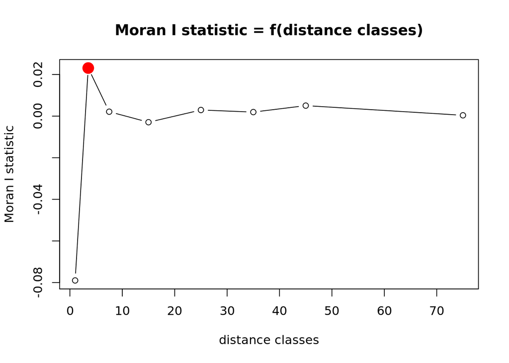

```r
ResidTic <- residuals(BrmTic, method = "posterior_predict")
MoranTic <- correlogFork(time = TicToc$Age[!is.na(TicToc$TIC)],
                          z = ResidTic[, 1], method = "Moran", breaks = Breaks)
plot(MoranTic)
```

```r
Threads <- 3
Sys.setenv(STAN_NUM_THREADS = Threads)
Nchains <- 4
Ncores <- 4
Inits <- setInitsTic(Seed = sample(73, Nchains), Length = Nchains, K = 2000)
BrmToc <- brm(TOC | weights(Weight) ~ gp(Age, k = 2000, c = 5/4),
              family = Beta(),
              data = TicToc,
              inits = Inits,
              cores = Ncores, chains = Nchains,
              iter = 3000, warmup = 1000, thin = 1, refresh = 0,
              threads = threading(Threads), backend = "cmdstanr",
              control = list(adapt_delta = 0.9, max_treedepth = 15))
```

```
## Running MCMC with 4 parallel chains, with 3 thread(s) per chain...
##
## Chain 3 finished in 6032.6 seconds.
## Chain 4 finished in 6039.8 seconds.
## Chain 2 finished in 6117.0 seconds.
## Chain 1 finished in 6205.5 seconds.
##
## All 4 chains finished successfully.
## Mean chain execution time: 6098.8 seconds.
## Total execution time: 6208.1 seconds.
```

```r
summary(BrmToc)
```

```
##  Family: beta
##   Links: mu = logit; phi = identity
## Formula: TOC | weights(Weight) ~ gp(Age, k = 2000, c = 5/4)
##    Data: TicToc (Number of observations: 2788)
##   Draws: 4 chains, each with iter = 2000; warmup = 0; thin = 1;
##          total post-warmup draws = 8000
##
## Gaussian Process Terms:
##               Estimate Est.Error l-95% CI u-95% CI Rhat Bulk_ESS Tail_ESS
## sdgp(gpAge)       0.39      0.01     0.36     0.42 1.00     3957     5539
## lscale(gpAge)     0.00      0.00     0.00     0.00 1.01      830     1331
##
## Population-Level Effects:
##           Estimate Est.Error l-95% CI u-95% CI Rhat Bulk_ESS Tail_ESS
## Intercept    -4.44      0.02    -4.48    -4.39 1.00    13007     5938
##
## Family Specific Parameters:
##     Estimate Est.Error l-95% CI u-95% CI Rhat Bulk_ESS Tail_ESS
## phi  3053.60    127.48  2797.79  3305.67 1.00     1218     1757
##
## Draws were sampled using sample(hmc). For each parameter, Bulk_ESS
## and Tail_ESS are effective sample size measures, and Rhat is the potential
## scale reduction factor on split chains (at convergence, Rhat = 1).
```

```r
PredToc <- predict(BrmToc, newdata = NewData)
```

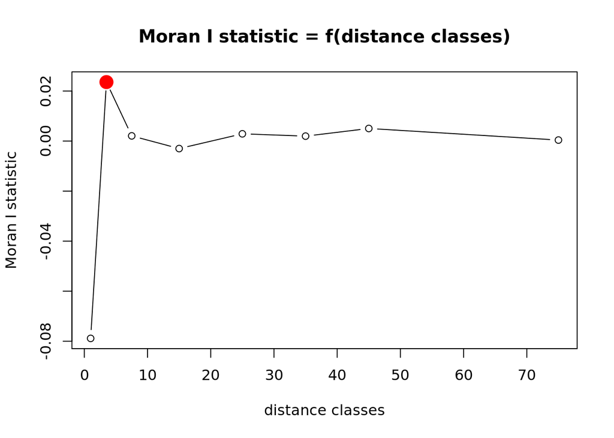

```r
ResidToc <- residuals(BrmTic, method = "posterior_predict")
MoranToc <- correlogFork(time = TicToc$Age[!is.na(TicToc$TOC)],
                          z = ResidToc[, 1], method = "Moran", breaks = Breaks)
plot(MoranToc)
```

#### Isotope

For the Gaussian process smoothing of the oxygen isotopes, we used a Gaussian distribution for the unbounded isotope values.

```r
Isotope <- Isotope[nrow(Isotope):1, ]
Isotope$Weight <- getWeight(Isotope$Age)

Nchains <- 4
Ncores <- 4
Threads <- 3
Sys.setenv(STAN_NUM_THREADS = Threads)
Inits <- setInitsIsotope(Seed = sample(73, Nchains), Length = Nchains, K = 600)
BrmIso <- brm(Lakewater | weights(Weight) ~ gp(Age, k = 600, c = 5/4, gr = FALSE),
              data = Isotope,
              init = Inits,
              family = gaussian(),
              chains = Nchains, cores = Ncores,
              iter = 2000, warmup = 1000, thin = 1, refresh = 0,
              threads = threading(Threads), backend = "cmdstanr",
              control = list(adapt_delta = 0.8, max_treedepth = 10))
```

```
## Running MCMC with 4 parallel chains, with 3 thread(s) per chain...
##
## Chain 4 finished in 397.6 seconds.
## Chain 2 finished in 403.9 seconds.
## Chain 1 finished in 421.3 seconds.
## Chain 3 finished in 422.1 seconds.
##
## All 4 chains finished successfully.
## Mean chain execution time: 411.2 seconds.
## Total execution time: 423.3 seconds.
```

```r
summary(BrmIso)
```

```
##  Family: gaussian
##   Links: mu = identity; sigma = identity
## Formula: Lakewater | weights(Weight) ~ gp(Age, k = 600, c = 5/4, gr = FALSE)
##    Data: Isotope (Number of observations: 1746)
##   Draws: 4 chains, each with iter = 1000; warmup = 0; thin = 1;
##          total post-warmup draws = 4000
##
## Gaussian Process Terms:
##               Estimate Est.Error l-95% CI u-95% CI Rhat Bulk_ESS Tail_ESS
## sdgp(gpAge)       1.42      0.09     1.26     1.59 1.00     1607     2240
## lscale(gpAge)     0.00      0.00     0.00     0.00 1.00     2254     2990
##
## Population-Level Effects:
##           Estimate Est.Error l-95% CI u-95% CI Rhat Bulk_ESS Tail_ESS
## Intercept    -6.16      0.13    -6.42    -5.89 1.00     6776     2653
##
## Family Specific Parameters:
##       Estimate Est.Error l-95% CI u-95% CI Rhat Bulk_ESS Tail_ESS
## sigma     0.53      0.01     0.51     0.55 1.00     5080     3007
##
## Draws were sampled using sample(hmc). For each parameter, Bulk_ESS
## and Tail_ESS are effective sample size measures, and Rhat is the potential
## scale reduction factor on split chains (at convergence, Rhat = 1).
```

```r
PredIso <- predict(BrmIso, newdata = NewData)
```

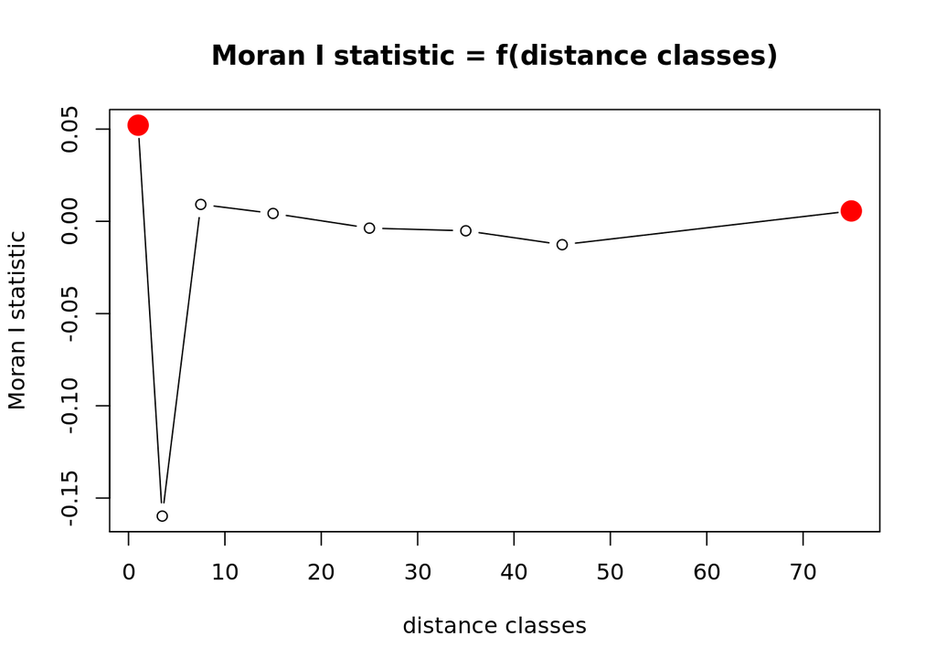

```r
ResidIso <- residuals(BrmIso, method = "posterior_predict")
MoranIso <- correlogFork(time = Isotope$Age[!is.na(Isotope$Lakewater)],
                         z = ResidIso[, 1], method = "Moran", breaks = Breaks)
plot(MoranIso)
```

#### Potassium

The Gaussian process modelling of Potassium has been performed on a computer with 64 GB of RAM. For less beefy machine, either increase Mid to 101 or use only one core and one chain.

```r
CaK <- CaK[nrow(CaK):1, ]
# Due to memory constraints, we used 21 point running mean instead of the 170,000 raw values
# Get the upper and lower index of the range to calculate the rolling means
Mid <- 21
Up <- (Mid + 1)/2
Lo <- (Mid - 1)/2
NrowCaK <- nrow(CaK)
From <- c(1:NrowCaK) - Lo
From[From < 1] <- 1
To <- c(1:NrowCaK) + Lo
To[To > NrowCaK] <- NrowCaK
FromTo <- cbind(From, To) # From where to where to calculate rolling means
# Get rolling means and standard errors
MeanSE <- apply(FromTo, 1, function(x) getRollingMeanSE(CaK[x[1]:x[2], "K"]))
MeanSE <- t(MeanSE)
# Convert to kilo counts
MeanSE <- MeanSE/1000
colnames(MeanSE) <- c("KRunMean", "KRunMeanSE")
 # Bind to raw data
CaK <- cbind(CaK, MeanSE)
# Get only every 21st row
Sel <- seq(1, nrow(CaK), by = Mid)
CaKSel <- CaK[Sel, ]
# Assign weights
CaKSel$Weight <- getWeight(CaKSel$Age)
```

```r
Nchains <- 4
Ncores <- 4
# No within-chain parallelization because this is the only time
# where it is not improving the speed of the smoothening.
Inits <- setInitsK(Seed = sample(73, Nchains), Length = Nchains, K = 4000)
# Response:
#   KRunMean: 21-point running mean of Potassium counts
#   + weights(Weight): Observational weights per Potassium sample (time captured by each sample);
#                      accounts for heteroskedasticity (Simpson, 2018)
#   + se(KRunMeanSE, sigma = TRUE): Calculated standard error of 21-point running mean;
#                                   sigma = TRUE to model sigma in addition to the known standard errors
#   + trunc(lb = 0): Truncated data distribution with lower boundary (lb) of 0.
# Predictor:
# ~ gp(Age, k = 400, c = 5/4, gr = FALSE): Gaussian process smoothing of age of the Potassium sample
BrmK <- brm(KRunMean | weights(Weight) + se(KRunMeanSE, sigma = TRUE) + trunc(lb = 0) ~
              gp(Age, k = 4000, c = 5/4),
            data = CaKSel,
            family = gaussian(), # Normal distribution but truncated at lower boundary of 0.
            inits = Inits,
            chains = Nchains,
            cores = Ncores,
            iter = 2000, warmup = 1000, thin = 1, refresh = 0,
            backend = "cmdstanr",
            control = list(adapt_delta = 0.9, max_treedepth = 15))
```

```
## Running MCMC with 4 parallel chains...
##
## Chain 3 finished in 52911.1 seconds.
## Chain 2 finished in 87749.6 seconds.
## Chain 4 finished in 179284.0 seconds.
## Chain 1 finished in 318123.0 seconds.
##
## All 4 chains finished successfully.
## Mean chain execution time: 159516.9 seconds.
## Total execution time: 318137.9 seconds.
```

```r
# Summarize posterior distribution of parameters and evaluate convergence through Rhat and ESS
summary(BrmK)
```

```
##  Family: gaussian
##   Links: mu = identity; sigma = identity
## Formula: KRunMean | weights(Weight) + se(KRunMeanSE, sigma = TRUE) + trunc(lb = 0) ~ gp(Age, k = 4000, c = 5/4)
##    Data: CaKSel (Number of observations: 8422)
##   Draws: 4 chains, each with iter = 1000; warmup = 0; thin = 1;
##          total post-warmup draws = 4000
##
## Gaussian Process Terms:
##               Estimate Est.Error l-95% CI u-95% CI Rhat Bulk_ESS Tail_ESS
## sdgp(gpAge)       1.84      0.04     1.76     1.92 1.00     1358     2377
## lscale(gpAge)     0.00      0.00     0.00     0.00 1.00      943     1213
##
## Population-Level Effects:
##           Estimate Est.Error l-95% CI u-95% CI Rhat Bulk_ESS Tail_ESS
## Intercept     5.46      0.08     5.31     5.62 1.00     5002     2862
##
## Family Specific Parameters:
##       Estimate Est.Error l-95% CI u-95% CI Rhat Bulk_ESS Tail_ESS
## sigma     0.42      0.01     0.41     0.42 1.00     1715     1806
##
## Draws were sampled using sample(hmc). For each parameter, Bulk_ESS
## and Tail_ESS are effective sample size measures, and Rhat is the potential
## scale reduction factor on split chains (at convergence, Rhat = 1).
```

```r
# Get smoothed values of Potassium for the same moments in time where we have a diatom assemblage.
NewDataK <- data.frame(Age = Comm$Age,
                      KRunMeanSE = mean(CaKSel$KRunMeanSE))
PredK <- predict(BrmK, newdata = NewDataK)
```

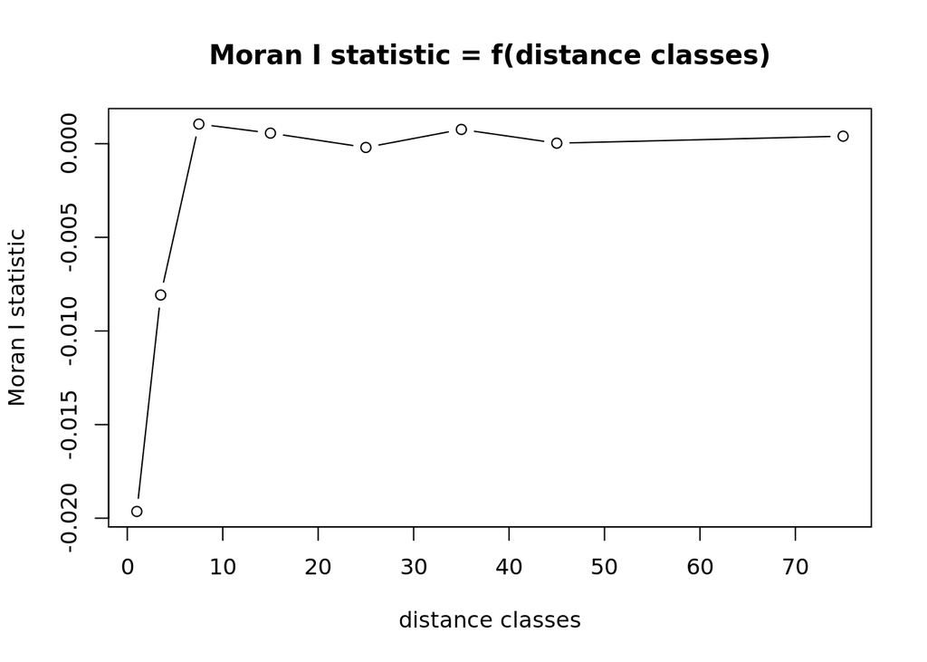

```r
ResidK <- residuals(BrmK, method = "posterior_predict")
MoranK <- correlogFork(time = CaKSel$Age[!is.na(CaKSel$KRunMean)],
                          z = ResidK[, 1], method = "Moran", breaks = Breaks)
plot(MoranK)
```

#### Grain size

For the Gaussian process smoothing of the grain size distribution, we used a Dirichlet distribution for the multivariate grain size composition because they are initial quantified as relative share and sum to 1. Grain size composition was the only multivariate local paleoenvironmental predictor and using all seven grain size categories to test for an influence on phylogenetic community structure increases the chances that one of them is identified to predict community structure. We therefore used the R package ‘robCompositions’ 2.3.1 (Filzmoser et al., 2018) to summarize grain size composition as the first principal component after an isometric logarithmic ratio transformation of the smoothened grain sizes.

```r
# Transfer the grainsizes to another data.frame
DataGrainsize <- Grainsize[, c("SAND","VERY_COARSE_SILT", "COARSE_SILT", "MEDIUM_SILT",
                               "FINE_SILT", "VERY_FINE_SILT", "CLAY")]
# Rename the columns with grainsizes to y1...y7
colnames(DataGrainsize) <- c("y1", "y2", "y3", "y4", "y5", "y6", "y7")
 # At all times the sum is 1
DataGrainsize <- DataGrainsize / rowSums(DataGrainsize)
 # Add the age of the samples
DataGrainsize$Age <- Grainsize$Age
# Assign weights
DataGrainsize$Weight <- getWeight(DataGrainsize$Age)
# Some inits fail but no way to set inits as list as with the other paleoenvironmental predictors
 # Number of chains
Nchains <- 4
 # Run only chain at a time
Ncores <- 1
 # within-chain parallelization on 6 cores
Threads <- 6
Sys.setenv(STAN_NUM_THREADS = Threads)
# Create empty list where we safe converged chains
BrmGrainsizeList <- vector(mode = "list")
# We start with a counter of zero successful attempts
Nsuccess <- 0
# Do while we have less successful attempts than desired chains
while (Nsuccess < Nchains) {
  # Response:
  #   bind(y1, y2, y3, y4, y5, y6, y7): multivariate grainsize distribution
  #   + weights(Weight): Observational weights per grainsize sample (time captured by each sample);
  #                      accounts for heteroskedasticity (Simpson, 2018)
  # Predictor:
  # ~ gp(Age, k = 10, c = 5/4, gr = FALSE): Gaussian process smoothing of age of the grainsize sample
  BrmGrainsize <- brm(bind(y1, y2, y3, y4, y5, y6, y7) | weights(Weight) ~
                        gp(Age, k = 10, c = 5/4, gr = FALSE),
                      data = DataGrainsize,
                      # Dirichlet distribution for proportions summing up to 1
                      family = dirichlet(),
                      chains = 1, cores = 1,
                      iter = 4000, warmup = 3000, thin = 1, refresh = 0,
                      threads = threading(Threads), backend = "cmdstanr",
                      control = list(adapt_delta = 0.99, max_treedepth = 18))
  SummaryBrmGrainsize <- summary(BrmGrainsize)
  # Check if attempt converged
  Converged <- all(c(SummaryBrmGrainsize$fixed[, "Rhat"] < 1.05, SummaryBrmGrainsize$gp[, "Rhat"] < 1.05))
  if (Converged) {
    # Increas success counter by 1; stop the while-loop if successes equals the desired number of chains
    Nsuccess <- Nsuccess + 1
    # Add attempt to the list of successful attempts (i.e. 4 at the end)
    BrmGrainsizeList[[Nsuccess]] <- BrmGrainsize
  }
}
```

```
## Running MCMC with 1 chain, with 6 thread(s) per chain...
```

[output not shown]

[output not shown]

[output not shown]

[output not shown]

[output not shown]

[output not shown]

```
## Chain 1 finished in 8318.7 seconds.
```

```
## Running MCMC with 1 chain, with 6 thread(s) per chain...
```

[output not shown]

[output not shown]

[output not shown]

[output not shown]

[output not shown]

[output not shown]

[output not shown]

[output not shown]

[output not shown]

[output not shown]

[output not shown]

[output not shown]

```
## Chain 1 finished in 9062.3 seconds.
```

```
## Running MCMC with 1 chain, with 6 thread(s) per chain...
##
## Chain 1 finished in 1344.8 seconds.
```

[output not shown]

```
## Running MCMC with 1 chain, with 6 thread(s) per chain...
##
## Chain 1 finished in 10475.2 seconds.
```

```
## Running MCMC with 1 chain, with 6 thread(s) per chain...
##
## Chain 1 finished in 8647.4 seconds.
```

```r
# Convert list with successful attempts to brms fit
BrmGrainsize <- combine_models(mlist = BrmGrainsizeList)

# Summarize posterior distribution of parameters and evaluate convergence through Rhat and ESS
summary(BrmGrainsize)
```

```
##  Family: dirichlet
##   Links: muy2 = logit; muy3 = logit; muy4 = logit; muy5 = logit; muy6 = logit; muy7 = logit; phi = identity
## Formula: bind(y1, y2, y3, y4, y5, y6, y7) | weights(Weight) ~ gp(Age, k = 10, c = 5/4, gr = FALSE)
##    Data: DataGrainsize (Number of observations: 697)
##   Draws: 4 chains, each with iter = 1000; warmup = 0; thin = 1;
##          total post-warmup draws = 4000
##
## Gaussian Process Terms:
##                    Estimate Est.Error l-95% CI u-95% CI Rhat Bulk_ESS Tail_ESS
## sdgp(muy2_gpAge)       1.19      0.80     0.38     3.23 1.00     1742     2533
## sdgp(muy3_gpAge)       2.13      1.05     0.84     4.78 1.00     2378     2879
## sdgp(muy4_gpAge)       2.67      1.12     1.21     5.40 1.00     3117     3223
## sdgp(muy5_gpAge)       3.10      1.22     1.49     6.14 1.00     2961     2848
## sdgp(muy6_gpAge)       2.94      1.19     1.44     5.97 1.00     2806     2892
## sdgp(muy7_gpAge)       2.53      1.01     1.23     5.09 1.00     2818     2871
## lscale(muy2_gpAge)     0.18      0.15     0.01     0.48 1.00      893     2258
## lscale(muy3_gpAge)     0.20      0.13     0.02     0.43 1.01     1062     2924
## lscale(muy4_gpAge)     0.15      0.11     0.02     0.34 1.00     1194     2662
## lscale(muy5_gpAge)     0.16      0.10     0.02     0.33 1.00     1158     2454
## lscale(muy6_gpAge)     0.15      0.10     0.02     0.32 1.00     1295     1881
## lscale(muy7_gpAge)     0.13      0.09     0.02     0.30 1.00     1680     2409
##
## Population-Level Effects:
##                Estimate Est.Error l-95% CI u-95% CI Rhat Bulk_ESS Tail_ESS
## muy2_Intercept     0.70      0.77    -1.52     1.70 1.00     2559     1503
## muy3_Intercept     0.98      1.15    -1.86     2.71 1.01     2143     2514
## muy4_Intercept     1.47      1.15    -1.23     3.48 1.00     2633     2256
## muy5_Intercept     1.24      1.35    -1.75     3.59 1.00     3057     2333
## muy6_Intercept     0.94      1.21    -1.75     3.03 1.00     3715     2792
## muy7_Intercept     1.21      1.03    -1.18     3.07 1.00     2935     2389
##
## Family Specific Parameters:
##     Estimate Est.Error l-95% CI u-95% CI Rhat Bulk_ESS Tail_ESS
## phi   156.23      3.40   149.73   162.92 1.00     6783     3067
##
## Draws were sampled using sample(hmc). For each parameter, Bulk_ESS
## and Tail_ESS are effective sample size measures, and Rhat is the potential
## scale reduction factor on split chains (at convergence, Rhat = 1).
```

```r
# Get smoothed values of grainsizes for the same moments in time where we have a diatom assemblage.
PredGrainsize <- predict(BrmGrainsize, newdata = NewData)

# Robust principle component analysis for predicted grainsize composition
# (i.e. individual proportions summing up to 1)
GrainsizePca <- pcaCoDa(PredGrainsize[, 1, ])

# See how much variance is explained by the first axis of the PCA
GrainsizePca$princompOutputClr$sdev^2 / sum(GrainsizePca$princompOutputClr$sdev^2)
```

```
##       Comp.1       Comp.2       Comp.3       Comp.4       Comp.5       Comp.6
## 0.7648936299 0.2080444395 0.0243634818 0.0011974373 0.0009274708 0.0005735407
```

```r
GrainsizePca <- GrainsizePca$scores
```

### 2.4.2 Climatic predictors

In addition to the predictors derived from the sediment record, we included the following climatic predictors in the regression analysis: the global benthic $\delta^{18}$O isotope stack LR04 (Lisiecki & Raymo, 2005), $\delta^{18}$O planktonic isotope ratios – Medstack (Wang et al., 2010), and northern hemisphere summer insolation at the latitude of Lake Ohrid (i.e. 41° N).

#### Oxygen isotope stacks LR04 and Medstack

To match the MPD values with the age of climatic predictors, LR04 and Medstack were linearly interpolated.

```r
colnames(LR04Values) <- c("Time", "d18O", "SE") # Replace column names which R does not get right
# Reorder from past (top) to present (bottom) as the assemblage and other predictors
LR04Values <- LR04Values[nrow(LR04Values):1, ]
LR04Values$Time <- -LR04Values$Time # Convert age to negative values as in Comm
# Reorder from past (top) to present (bottom) as the assemblage and other predictors
Gast <- Gast[nrow(Gast):1, ]
Gast$Age <- -Gast$Age # Convert age to negative values as in Comm
Medstack <- Medstack[nrow(Medstack):1, ] # Reorder from past to present as the assemblage and other predictors
# Linear interpolation to the ages of diatom assemblages (i.e. Comm$Age)
LR04Comm <- approx(x = LR04Values$Time, y = LR04Values$d18O, xout = Comm$Age)$y
GastComm <- approx(x = Gast$Age, y = Gast$Temp, xout = Comm$Age)$y
MedstackComm <- approx(x = -Medstack$Age, y = Medstack$d18Ostack, xout = Comm$Age)$y
```

#### Summer insolation

```r
Times <- Comm$Age * 1000 # Convert kilo years to million years
Obls <- sapply(Times, ber78) # Get Orbit
```

```
## load BER78data
```

```r
Insolation41 <- apply(Obls, 2, function(x) Insol_d1d2(orbit = x[1:3],
                                                      d1 = 171, # 0AM of summer solstice
                                                      d2 = 172, # 12PM of summer solstice
                                                      lat = 41*pi/180, # Latitude of Lake Ohrid
                                                      # Energy received by the Earth from the Sun per unit of time per
                                                      # unit of area on a theoretical surface perpendicular to the
                                                      # Sun’s rays at the distance a
                                                      S0 = 1368,
                                                      avg = TRUE)) # Unit: W/m2
```

### 2.4.3 Intrinsic biological predictors

To assess the impact of diatom intrinsic changes (e.g. speciation, extinction, and population dynamics) on assembly processes and to avoid spurious effects of local paleoenvironmental and climatic predictors, we included time as a predictor and allowed for discrete shifts in MPD at a given moment in time. The number of shifts were estimated with a change point analysis in the R package “ecp” 3.1.0 (James & Matteson, 2015). The same number of shifts or less (depending on whether time shifts could be explained by paleoenvironmental and/or climate predictors) were allowed in the regression analysis. Ages of the shifts were not fixed as these might change when inferred together with paleoenvironmental and/or climate influence on MPD.

```r
Eag <- e.agglo(matrix(SesMpd[-1], ncol = 1), # Time-series of SES MPD
               member = 1:length(SesMpd[-1])) # Initial membership, every assemblage in its own group
Comm$Age[-1][Eag$estimates] # Show ages of the estimated shifts
```

```
## [1] -621.2070 -417.5220 -165.1314 -143.1743  -28.2461  -14.1485
```

### 2.4.4 Response of deterministic assembly processes to local paleoenvironmental, climatic, and intrinsic biological predictors

For our regression model, we excluded colinear local paleoenvironmental and climatic predictors from the analysis (pearson correlation > |0.7|) and retained the following predictors: grain size, isotope composition, potassium, TOC, deciduous oaks, Medstack, insolation and time and time shifts as biological predictors.

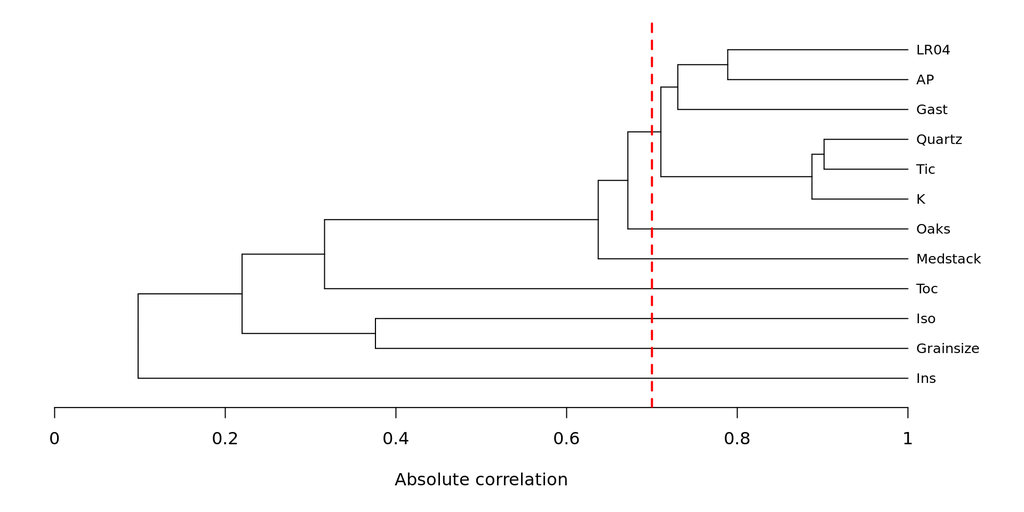

```r
# Grainsize PCA may vary between MCMC runs
# Low values should always indicate a small lake
if (GrainsizePca[1, 1] < GrainsizePca[nrow(GrainsizePca), 1]) {
  GrainsizePca <- -1 * GrainsizePca
}
DataRegr <- data.frame(Age = Comm$Age,
                       Mpd = SesMpd,
                       Tic = PredTic[, 1] * 100, # Convert proportion [0,1] to percentage [0, 100]
                       Toc = PredToc[, 1] * 100, # Convert proportion [0,1] to percentage [0, 100]
                       AP = PredAP[, 1],
                       Oaks = PredOaks[, 1],
                       Quartz = PredQuartz[, 1],
                       Grainsize = GrainsizePca[, 1],
                       Iso = PredIso[, 1],
                       K = PredK[, 1],
                       Ins = Insolation41,
                       LR04 = LR04Comm,
                       Gast = GastComm,
                       Medstack = MedstackComm)
DataRegr$Weight <- getWeight(DataRegr$Age) # Add weights to data.frame
# Get pearson's correlation for all predictors (but not including Age or MPD)
EnvCor <- cor(DataRegr[, -c(1, 2, ncol(DataRegr))])
# Take absolute correlation strength and convert to distance measure between predictors
EnvCorDist <- as.dist(1 - abs(EnvCor))
EnvCorClust <- hclust(EnvCorDist, method = "average") # Do UPGMA clustering
par(mar = c(5.1, 1, 1, 4))
plot(as.dendrogram(EnvCorClust), # convert hclust object to dendrogram for plotting
     horiz = TRUE, # horizontal orientation
     main = "", xlab = "Absolute correlation",
     ylab = "", yaxt = "n", # No y-label or axis ticks
     xlim = c(1, 0), # Limit of x-axis [0,1]
     nodePar = list(pch = NA, lab.cex = 0.8))
axis(side = 1, at = seq(0, 1, 0.2), labels = seq(1, 0, -0.2)) # Add ticks to x-axis
abline(v = 0.3, lty = 2, lwd = 2, col = "red") # Add dashed red line at pearson correlation strength of |0.7|
```

Dendrogram showing collinearity of paleoenvironmental proxies.

Local paleoenvironmental, climatic, and intrinsic predictors were centered to 0 and scaled to a variance of 1 to compare the strength of their influences on MPD (i.e. $\beta$). This will help to compare their influence on the mean phylogenetic distance of the diatom assemblages (MPD).

```r
# Get indices of the period
# (i.e. time between two shifts or between a shift and the upper/lower age boundary)
# for all assemblages in Comm
DataRegr$Period <- as.factor(findInterval(Comm$Age, Comm$Age[-1][Eag$estimates]) + 1)
# Response plots after regression analysis should not use scaled predictors.
# We need the mean and sd to rescale plots to the original scale of the predictors.
# No need for MPD, Weight and factor shift at position c(2, 15, 16)
DataRegrMean <- colMeans(DataRegr[, -c(2, 15, 16)], na.rm = TRUE)
DataRegrSd <- apply(DataRegr[, -c(2, 15, 16)], 2, sd, na.rm = TRUE)
# Scale all predictors to mean of 0 and standard error of 1 with scale()
DataRegr$Tic = scale(DataRegr$Tic)[, 1]
DataRegr$Toc = scale(DataRegr$Toc)[, 1]
DataRegr$AP = scale(DataRegr$AP)[, 1]
DataRegr$Oaks = scale(DataRegr$Oaks)[, 1]
DataRegr$Quartz = scale(DataRegr$Quartz)[, 1]
DataRegr$Grainsize = scale(DataRegr$Grainsize)[, 1]
DataRegr$Iso = scale(DataRegr$Iso)[, 1]
DataRegr$K = scale(DataRegr$K)[, 1]
DataRegr$Ins = scale(DataRegr$Ins)[, 1]
DataRegr$LR04 = scale(DataRegr$LR04)[, 1]
DataRegr$Gast = scale(DataRegr$Gast)[, 1]
DataRegr$Medstack = scale(DataRegr$Medstack)[, 1]
DataRegr$AgeScaled <- scale(DataRegr$Age)[, 1]
# The predictor time cannot have mean of 0 because of the specification
# of the MPD regression model. We substract the maximum.
DataRegr$Age <- (DataRegr$AgeScaled - max(DataRegr$AgeScaled)) * -1
```

```r
# Response:
#   Mpd: Standardized effect size of the mean phylogenetic distance between diatoms of an assemblage
#        of an assemblage; at 380 moments in time
#   + weights(Weight): Observational weights per diatom sample (time captured by each sample);
#                      accounts for heteroskedasticity (Simpson, 2018)
# Predictors:
#  Local paleoenvironment:
#  ~ Grainsize: Axis 1 of principle component analyses of smoothened grainsize distribution
#    Iso: Smoothened oxygen isotopes
#    K: Smoothened Potassium counts
#    Oaks: Smoothened relativ abundance of oak pollen
#    Toc: Smoothened TOC concentration
#  Climate:
#    Ins: Insolation at 41°
#    Medstack: planktonic isotope ratios
#  Intrinsic biological predictors:
#    AgeScaled: Age of the diatom sample
#    bS1-bS6: Change in MPD relative to the intercept bS7
MpdRegr <- brms::bf(Mpd | weights(Weight) ~
                      bGrain * Grainsize + # Effect of Grainsize
                      bIso * Iso + # Effect of Oxygen isotopes
                      bK * K + # Effect of Potassium
                      bOaks * Oaks + # Effect of Oaks
                      bToc * Toc + # Effect of TOC
                      bIns * Ins + # Effect of Insolation
                      bMed * Medstack + # Effect of Medstack record
                      bAge * AgeScaled + # Effect of Age
                      bS7 + # MPD older than earliest shift (#6)
                      bS6 * inv_logit((Age - o5) * 300) * inv_logit((o6 - Age) * 300) + # MPD between Shift 5 & 6
                      bS5 * inv_logit((Age - o4) * 300) * inv_logit((o5 - Age) * 300) + # MPD between Shift 4 & 5
                      bS4 * inv_logit((Age - o3) * 300) * inv_logit((o4 - Age) * 300) + # MPD between Shift 3 & 4
                      bS3 * inv_logit((Age - o2) * 300) * inv_logit((o3 - Age) * 300) + # MPD between Shift 2 & 3
                      bS2 * inv_logit((Age - o1) * 300) * inv_logit((o2 - Age) * 300) + # MPD between Shift 1 & 2
                      bS1 * inv_logit((o1 - Age) * 300), # MPD younger than Shift1
                    # keep omega within the range of predictor
                    # 3.242474 is the max of (DataRegr$AgeScaled - max(DataRegr$AgeScaled)) * -1
                    brms::nlf(o1 ~ inv_logit(S6 - S5 - S4 - S3 - S2 - S1) * 3.242474),
                    brms::nlf(o2 ~ inv_logit(S6 - S5 - S4 - S3 - S2) * 3.242474),
                    brms::nlf(o3 ~ inv_logit(S6 - S5 - S4 - S3) * 3.242474),
                    brms::nlf(o4 ~ inv_logit(S6 - S5 - S4) * 3.242474),
                    brms::nlf(o5 ~ inv_logit(S6 - S5) * 3.242474),
                    brms::nlf(o6 ~ inv_logit(S6) * 3.242474),
                    # Model parameter to be inferred:
                    bS1 + bS2 + bS3 + bS4 + bS5 + bS6 + bS7 + S1 + S2 + S3 + S4 + S5 + S6 ~ 1,
                    bGrain + bIso + bK + bOaks + bToc + bIns + bMed + bAge ~ 1,
                    nl = TRUE)
```

```r
MpdPrior <- c(# Prior for paleoenvironmental and climatic predictors
              # Centered in 0 (i.e. no effect) and a large variance of 1
              prior(normal(0, 1), nlpar = "bGrain"),
              prior(normal(0, 1), nlpar = "bIso"),
              prior(normal(0, 1), nlpar = "bK"),
              prior(normal(0, 1), nlpar = "bOaks"),
              prior(normal(0, 1), nlpar = "bToc"),
              prior(normal(0, 1), nlpar = "bIns"),
              prior(normal(0, 1), nlpar = "bMed"),
              # Prior for intrinsic biological predictor
              # (linear change in MPD with age of the diatom assemblage)
              # Centered in 0 (i.e. no effect) and a large variance of 1
              prior(normal(0, 1), nlpar = "bAge"),
              # Prior for the effect of the shifts
              # Centered in 0 (i.e. no effect) and a large variance of 1
              prior(normal(0, 1), nlpar = "bS1"),
              prior(normal(0, 1), nlpar = "bS2"),
              prior(normal(0, 1), nlpar = "bS3"),
              prior(normal(0, 1), nlpar = "bS4"),
              prior(normal(0, 1), nlpar = "bS5"),
              prior(normal(0, 1), nlpar = "bS6"),
              prior(normal(0, 1), nlpar = "bS7"),
              # Prior for the ages of the shifts
              # Prior for the earliest shift:
              prior(normal(0, 2), nlpar = "S6", lb = -5, ub = 5),
              # The age of the 2nd oldest shift is given by S6 minus S5.
              # Hence S5 must be positive (otherwise 2nd shift will be earlier than the 1st shift!).
              # We constrain the parameter to be positive through an exponential prior.
              prior(exponential(2), nlpar = "S5", lb = 0),
              prior(exponential(2), nlpar = "S4", lb = 0),
              prior(exponential(2), nlpar = "S3", lb = 0),
              prior(exponential(2), nlpar = "S2", lb = 0),
              prior(exponential(2), nlpar = "S1", lb = 0))
```

We use Bayesian inference to obtain all parameters of the regression model through similar Hamiltonian Monte Carlo sampling using the “brms” package (details in Supporting Information Appendix 5, Table S7).

```r
Nchains <- 4 # Run four chains
Ncores <- 4 # All chains in parallel on indiviudal CPU core
Threads <- 4 # Within-chain parallelization (i.e. 4 x 4 cores used)
# Get initial values from where we start Hamiltonian Monte Carlo sampling
Inits <- setInitsRegr(Seed = sample(123456, Nchains), Length = Nchains)
```

```r
Sys.setenv(STAN_NUM_THREADS = Threads)
FitMpd <- brm(MpdRegr,
              data = DataRegr,
              inits = Inits,
              prior = MpdPrior,
              cores = Ncores, chains = Nchains,
              iter = 60000, warmup = 50000, refresh = 0, thin = 2,
              threads = threading(Threads), backend = "cmdstanr",
              # Save prior draws to assess later their influence on posterior samples
              sample_prior = TRUE,
              control = list(adapt_delta = 0.999, max_treedepth = 20))
```

```
## Running MCMC with 4 parallel chains, with 4 thread(s) per chain...
##
## Chain 2 finished in 9292.5 seconds.
## Chain 4 finished in 9872.8 seconds.
## Chain 3 finished in 15041.5 seconds.
## Chain 1 finished in 69655.0 seconds.
##
## All 4 chains finished successfully.
## Mean chain execution time: 25965.4 seconds.
## Total execution time: 69655.3 seconds.
```

```r
summary(FitMpd)
```

[output not shown]

[output cut: 10 more lines]

```
## bIso_Intercept      -0.04      0.02    -0.07    -0.01 1.00     8536    16134
## bK_Intercept        -0.02      0.02    -0.05     0.02 1.00     9708    15092
## bOaks_Intercept      0.04      0.02    -0.01     0.08 1.00     2294     9435
## bToc_Intercept      -0.01      0.01    -0.04     0.01 1.00    13834    17230
## bIns_Intercept      -0.01      0.01    -0.04     0.02 1.00     9836    16215
## bMed_Intercept      -0.00      0.02    -0.04     0.04 1.00     2002     6730
## bAge_Intercept       0.37      0.05     0.26     0.47 1.00     1235     3827
##
## Family Specific Parameters:
##       Estimate Est.Error l-95% CI u-95% CI Rhat Bulk_ESS Tail_ESS
## sigma     0.23      0.01     0.21     0.24 1.00    19094    18528
##
## Draws were sampled using sample(hmc). For each parameter, Bulk_ESS
## and Tail_ESS are effective sample size measures, and Rhat is the potential
## scale reduction factor on split chains (at convergence, Rhat = 1).
```

The influence of local paleoenvironmental and climatic predictors on MPD was quantified by calculating a partial $R^{2}$, which is defined as the Bayesian $R^{2}$ (Gelman et al., 2019) of the full regression model minus the $R^{2}$ of a model without inferring the effect of these environmental predictors.

Calculate partial $R^{2}$ of the effects of shifts, time and environment by subtracting from the $R^{2}$ of the full model including all predictors (i.e. `r, eval = FALSE FitMpd`) the $R^{2}$ of a model without shifts (i.e. `r, eval = FALSE MpdNoShiftRegr`), without the linear relationship with time (i.e. `r, eval = FALSE MpdNoTimeRegr`), and without environmental predictors (i.e. `r, eval = FALSE MpdNoEnvRegr`).

The model without shifts.

```r
MpdNoShiftRegr <- brms::bf(Mpd | weights(Weight) ~
                             bAge * AgeScaled + # Effect of Age
                             bGrain * Grainsize + # Effect of Grainsize
                             bIns * Ins + # Effect of Insolation
                             bIso * Iso + # Effect of Oxygen isotopes
                             bK * K + # Effect of Potassium
                             bMed * Medstack + # Effect of Medstack record
                             bOaks * Oaks + # Effect of Oaks
                             bToc * Toc + # Effect of TOC
                             bS7, # Intercept
                           # Model parameter to be inferred:
                           bS7 ~ 1,
                           bAge + bGrain + bIns + bIso + bK + bMed + bOaks + bToc ~ 1,
                           nl = TRUE)
MpdNoShiftPrior <- c(prior(normal(0, 1), nlpar = "bAge"),
                     prior(normal(0, 1), nlpar = "bGrain"),
                     prior(normal(0, 1), nlpar = "bIns"),
                     prior(normal(0, 1), nlpar = "bIso"),
                     prior(normal(0, 1), nlpar = "bK"),
                     prior(normal(0, 1), nlpar = "bMed"),
                     prior(normal(0, 1), nlpar = "bOaks"),
                     prior(normal(0, 1), nlpar = "bToc"),
                     prior(normal(0, 1), nlpar = "bS7"))
FitMpdNoShift <- brm(MpdNoShiftRegr,
                     data = DataRegr,
                     inits = Inits,
                     prior = MpdNoShiftPrior,
                     cores = Ncores, chains = Nchains,
                     iter = 10000, warmup = 5000, refresh = 0, thin = 2,
                     threads = threading(Threads), backend = "cmdstanr",
                     control = list(adapt_delta = 0.999, max_treedepth = 20))
summary(FitMpdNoShift) # Check convergence
```

The model without a linear effect of time on MPD.

```r
MpdNoTimeRegr <- brms::bf(Mpd | weights(Weight) ~
                            bGrain * Grainsize +
                            bIns * Ins +
                            bIso * Iso +
                            bK * K +
                            bMed * Medstack +
                            bOaks * Oaks +
                            bToc * Toc +
                            bS7 + # Older than earliest shift (6)
                            bS6 * inv_logit((Age - o5) * 300) * inv_logit((o6 - Age) * 300) + # Between Shift 5 and 6
                            bS5 * inv_logit((Age - o4) * 300) * inv_logit((o5 - Age) * 300) + # Between Shift 4 and 5
                            bS4 * inv_logit((Age - o3) * 300) * inv_logit((o4 - Age) * 300) + # Between Shift 3 and 4
                            bS3 * inv_logit((Age - o2) * 300) * inv_logit((o3 - Age) * 300) + # Between Shift 2 and 3
                            bS2 * inv_logit((Age - o1) * 300) * inv_logit((o2 - Age) * 300) + # Between Shift 1 and 2
                            bS1 * inv_logit((o1 - Age) * 300), # Younger than Shift1
                          # keep omega within the range of predictor
                          brms::nlf(o1 ~ inv_logit(S6 - S5 - S4 - S3 - S2 - S1) * 3.242474),
                          brms::nlf(o2 ~ inv_logit(S6 - S5 - S4 - S3 - S2) * 3.242474),
                          brms::nlf(o3 ~ inv_logit(S6 - S5 - S4 - S3) * 3.242474),
                          brms::nlf(o4 ~ inv_logit(S6 - S5 - S4) * 3.242474),
                          brms::nlf(o5 ~ inv_logit(S6 - S5) * 3.242474),
                          brms::nlf(o6 ~ inv_logit(S6) * 3.242474),
                          bS1 + bS2 + bS3 + bS4 + bS5 + bS6 + bS7 + S1 + S2 + S3 + S4 + S5 + S6 ~ 1,
                          bGrain + bIns + bIso + bK + bMed + bOaks + bToc ~ 1,
                          nl = TRUE)
MpdNoTimePrior <- c(prior(normal(0, 1), nlpar = "bGrain"),
                    prior(normal(0, 1), nlpar = "bIns"),
                    prior(normal(0, 1), nlpar = "bIso"),
                    prior(normal(0, 1), nlpar = "bK"),
                    prior(normal(0, 1), nlpar = "bMed"),
                    prior(normal(0, 1), nlpar = "bOaks"),
                    prior(normal(0, 1), nlpar = "bToc"),
                    prior(normal(0, 1), nlpar = "bS1"),
                    prior(normal(0, 1), nlpar = "bS2"),
                    prior(normal(0, 1), nlpar = "bS3"),
                    prior(normal(0, 1), nlpar = "bS4"),
                    prior(normal(0, 1), nlpar = "bS5"),
                    prior(normal(0, 1), nlpar = "bS6"),
                    prior(normal(0, 1), nlpar = "bS7"),
                    prior(exponential(2), nlpar = "S1", lb = 0),
                    prior(exponential(2), nlpar = "S2", lb = 0),
                    prior(exponential(2), nlpar = "S3", lb = 0),
                    prior(exponential(2), nlpar = "S4", lb = 0),
                    prior(exponential(2), nlpar = "S5", lb = 0),
                    prior(normal(0, 2), nlpar = "S6", lb = -5, ub = 5))
FitMpdNoTime <- brm(MpdNoTimeRegr,
                    data = DataRegr,
                    inits = Inits,
                    prior = MpdNoTimePrior,
                    cores = Ncores, chains = Nchains,
                    iter = 50000, warmup = 45000, refresh = 0, thin = 2,
                    threads = threading(Threads),
                    backend = "cmdstanr",
                    control = list(adapt_delta = 0.999, max_treedepth = 20))
summary(FitMpdNoTime) # Check convergence
```

The model without any environmental predictor.

```r
MpdNoEnvRegr <- brms::bf(Mpd | weights(Weight) ~
                           bAge * AgeScaled +
                           bS7 + # Older than earliest shift (6)
                           bS6 * inv_logit((Age - o5) * 300) * inv_logit((o6 - Age) * 300) + # Between Shift 5 and 6
                           bS5 * inv_logit((Age - o4) * 300) * inv_logit((o5 - Age) * 300) + # Between Shift 4 and 5
                           bS4 * inv_logit((Age - o3) * 300) * inv_logit((o4 - Age) * 300) + # Between Shift 3 and 4
                           bS3 * inv_logit((Age - o2) * 300) * inv_logit((o3 - Age) * 300) + # Between Shift 2 and 3
                           bS2 * inv_logit((Age - o1) * 300) * inv_logit((o2 - Age) * 300) + # Between Shift 1 and 2
                           bS1 * inv_logit((o1 - Age) * 300), # Younger than Shift1
                         # keep omega within the range of predictor
                         brms::nlf(o1 ~ inv_logit(S6 - S5 - S4 - S3 - S2 - S1) * 3.242474),
                         brms::nlf(o2 ~ inv_logit(S6 - S5 - S4 - S3 - S2) * 3.242474),
                         brms::nlf(o3 ~ inv_logit(S6 - S5 - S4 - S3) * 3.242474),
                         brms::nlf(o4 ~ inv_logit(S6 - S5 - S4) * 3.242474),
                         brms::nlf(o5 ~ inv_logit(S6 - S5) * 3.242474),
                         brms::nlf(o6 ~ inv_logit(S6) * 3.242474),
                         bS1 + bS2 + bS3 + bS4 + bS5 + bS6 + bS7 + S1 + S2 + S3 + S4 + S5 + S6 ~ 1,
                         bAge ~ 1,
                         nl = TRUE)
MpdNoEnvPrior <- c(prior(normal(0, 1), nlpar = "bAge"),
                   prior(normal(0, 1), nlpar = "bS1"),
                   prior(normal(0, 1), nlpar = "bS2"),
                   prior(normal(0, 1), nlpar = "bS3"),
                   prior(normal(0, 1), nlpar = "bS4"),
                   prior(normal(0, 1), nlpar = "bS5"),
                   prior(normal(0, 1), nlpar = "bS6"),
                   prior(normal(0, 1), nlpar = "bS7"),
                   prior(exponential(2), nlpar = "S1", lb = 0),
                   prior(exponential(2), nlpar = "S2", lb = 0),
                   prior(exponential(2), nlpar = "S3", lb = 0),
                   prior(exponential(2), nlpar = "S4", lb = 0),
                   prior(exponential(2), nlpar = "S5", lb = 0),
                   prior(normal(0, 2), nlpar = "S6", lb = -5, ub = 5))
FitMpdNoEnv <- brm(MpdNoEnvRegr,
                   data = DataRegr,
                   inits = Inits,
                   prior = MpdNoEnvPrior,
                   cores = Ncores, chains = Nchains,
                   iter = 50000, warmup = 45000, refresh = 0, thin = 2,
                   threads = threading(Threads),
                   backend = "cmdstanr",
                   control = list(adapt_delta = 0.999, max_treedepth = 20))
summary(FitMpdNoEnv) # Check convergence
```

```r
# Table of inferred coefficients
################################
# Ages of shift are parameterized as additive
# (e.g.: age shift 2: sum of coefs for shifts 1 and 2 and transform them via inv_logit to time)
# Because of the sum shift 2 is never younger than shift 1.
# Get summary of coefficients
FixeffMpd <- fixef(FitMpd)
FitMpdDraws <- prepare_predictions(FitMpd) # Get sampled coefficients
S1 <- FitMpdDraws$nlpars$S1$fe$b[, 1] # Latest shift time
S2 <- FitMpdDraws$nlpars$S2$fe$b[, 1]
S3 <- FitMpdDraws$nlpars$S3$fe$b[, 1]
S4 <- FitMpdDraws$nlpars$S4$fe$b[, 1]
S5 <- FitMpdDraws$nlpars$S5$fe$b[, 1]
S6 <- FitMpdDraws$nlpars$S6$fe$b[, 1] # Earliest shift time
# Transform inferred coefficients to shift times with brms:::inv_logit
S1trans <- brms:::inv_logit(S6 - S5 - S4 - S3 - S2 - S1) * -1364.7
S2trans <- brms:::inv_logit(S6 - S5 - S4 - S3 - S2) * -1364.7
S3trans <- brms:::inv_logit(S6 - S5 - S4 - S3) * -1364.7
S4trans <- brms:::inv_logit(S6 - S5 - S4) * -1364.7
S5trans <- brms:::inv_logit(S6 - S5) * -1364.7
S6trans <- brms:::inv_logit(S6) * -1364.7
# Get mean, standard deviation and 95% credible interval for the transformed ages of the shift
FixeffMpd[8, ] <- c(mean(S1trans), sd(S1trans), quantile(S1trans, c(0.025, 0.975))[2:1])
FixeffMpd[9, ] <- c(mean(S2trans), sd(S2trans), quantile(S2trans, c(0.025, 0.975))[2:1])
FixeffMpd[10, ] <- c(mean(S3trans), sd(S3trans), quantile(S3trans, c(0.025, 0.975))[2:1])
FixeffMpd[11, ] <- c(mean(S4trans), sd(S4trans), quantile(S4trans, c(0.025, 0.975))[2:1])
FixeffMpd[12, ] <- c(mean(S5trans), sd(S5trans), quantile(S5trans, c(0.025, 0.975))[2:1])
FixeffMpd[13, ] <- c(mean(S6trans), sd(S6trans), quantile(S6trans, c(0.025, 0.975))[2:1])
# Omit term "Intercept" from coefficient names
rownames(FixeffMpd) <- gsub("_Intercept", "", rownames(FixeffMpd))
```

```r
kable(FixeffMpd, row.names = TRUE, align = "r", digits = 4)
```

|  | Estimate | Est.Error | Q2.5 | Q97.5 |
| --- | --- | --- | --- | --- |
| bS1 | -0.7808 | 0.1965 | -1.1531 | -0.3878 |
| bS2 | 0.6058 | 0.1871 | 0.2502 | 0.9832 |
| bS3 | -0.6691 | 0.1207 | -0.8937 | -0.4249 |
| bS4 | 1.3305 | 0.1404 | 1.0585 | 1.6087 |
| bS5 | -0.3655 | 0.0879 | -0.5307 | -0.1886 |
| bS6 | 0.4833 | 0.0619 | 0.3635 | 0.6061 |
| bS7 | -0.5142 | 0.0453 | -0.6067 | -0.4315 |
| S1 | -13.2649 | 0.8498 | -11.4831 | -14.8500 |
| S2 | -27.5759 | 1.1876 | -25.1320 | -29.8969 |
| S3 | -141.3449 | 0.6005 | -140.1093 | -142.4604 |
| S4 | -165.2382 | 0.6037 | -164.1271 | -166.4892 |
| S5 | -423.3528 | 6.7105 | -416.2838 | -437.4696 |
| S6 | -597.2078 | 20.1714 | -571.0346 | -626.1557 |
| bGrain | -0.0333 | 0.0178 | -0.0685 | 0.0010 |
| bIso | -0.0384 | 0.0168 | -0.0716 | -0.0061 |
| bK | -0.0165 | 0.0199 | -0.0547 | 0.0230 |
| bOaks | 0.0381 | 0.0222 | -0.0051 | 0.0815 |
| bToc | -0.0144 | 0.0140 | -0.0417 | 0.0131 |
| bIns | -0.0106 | 0.0133 | -0.0366 | 0.0153 |
| bMed | -0.0026 | 0.0194 | -0.0399 | 0.0359 |
| bAge | 0.3697 | 0.0520 | 0.2638 | 0.4655 |

Next, we are displaying the inferred parameters and effects in a caterpillar plot. This basically visualizes Table S8.

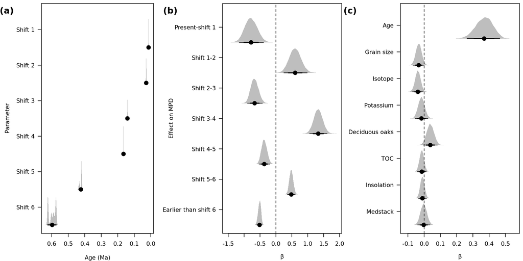

```r
DrawsShiftEffects <- data.frame(bS7 = FitMpdDraws$nlpars$bS7$fe$b[, 1],
                                bS6 = FitMpdDraws$nlpars$bS6$fe$b[, 1],
                                bS5 = FitMpdDraws$nlpars$bS5$fe$b[, 1],
                                bS4 = FitMpdDraws$nlpars$bS4$fe$b[, 1],
                                bS3 = FitMpdDraws$nlpars$bS3$fe$b[, 1],
                                bS2 = FitMpdDraws$nlpars$bS2$fe$b[, 1],
                                bS1 = FitMpdDraws$nlpars$bS1$fe$b[, 1])
DrawsShiftAges <- data.frame(S6 = S6trans,
                             S5 = S5trans,
                             S4 = S4trans,
                             S3 = S3trans,
                             S2 = S2trans,
                             S1 = S1trans)
DrawsEnvEffects <- data.frame(bMed = FitMpdDraws$nlpars$bMed$fe$b[, 1],
                              bIns = FitMpdDraws$nlpars$bIns$fe$b[, 1],
                              bToc = FitMpdDraws$nlpars$bToc$fe$b[, 1],
                              bOaks = FitMpdDraws$nlpars$bOaks$fe$b[, 1],
                              bK = FitMpdDraws$nlpars$bK$fe$b[, 1],
                              bIso = FitMpdDraws$nlpars$bIso$fe$b[, 1],
                              bGrain = FitMpdDraws$nlpars$bGrain$fe$b[, 1],
                              bAge = FitMpdDraws$nlpars$bAge$fe$b[, 1])
# Figure with three panels
layout(matrix(1:3, ncol = 3, nrow = 1), widths = c(0.32, 0.34, 0.34))
Prob <- c(0.75, 0.95) # Width credible interval
LwdProb <- c(1, 2) # Line-width credible interval
# Draw caterpillar plot for shift effects
par(las = 1, mar = c(4, 6, 0.5, 2))
caterpillar(Draws = DrawsShiftAges, Prob = c(0.75, 0.95), LwdProb = LwdProb,
            Xlab = "Age (Ma)", Ylab = "",
            Yticks = c("Shift 6", "Shift 5", "Shift 4",
                       "Shift 3", "Shift 2", "Shift 1"),
            ColLines = "black",
            AddDensity = TRUE, ColDensity = "grey",
            AddVertZero = FALSE,
            Xaxt = "n") # No plotting of x-axis ticks because they are in ka and we use Ma in the manuscript
axis(side = 1, at = seq(-600, 0, by = 100),
     labels = c("0.6", "0.5", "0.4", "0.3", "0.2", "0.1", "0.0")) # Add x-axis ticks
# Add label y-axis
text(x = -870, y = 4, labels = "Parameter", srt = 90, xpd = TRUE)
# Add panel index
mtext(text = "(a)", side = 2, line = 4,
      at = par("usr")[4] - diff(par("usr")[3:4]) * 0.03,
      font = 2, cex = 1.0)
# Draw caterpillar plot for shift effects
par(las = 1, mar = c(4, 8, 0.5, 0.5))
caterpillar(Draws = DrawsShiftEffects, Prob = c(0.75, 0.95), LwdProb = LwdProb,
            Xlab = expression(beta), Ylab = "",
             Yticks = c("Earlier than shift 6",
                       "Shift 5-6",
                       "Shift 4-5",
                       "Shift 3-4",
                       "Shift 2-3",
                       "Shift 1-2",
                       "Present-shift 1"),
            ColLines = "black",
            AddDensity = TRUE, ColDensity = "grey")
# Add label y-axis
text(x = -3.3, y = 4.5, labels = "Effect on MPD", srt = 90, xpd = TRUE)
# Add panel index
mtext(text = "(b)", side = 2, line = 6.5,
      at = par("usr")[4] - diff(par("usr")[3:4]) * 0.03,
      font = 2, cex = 1.0)
# Draw caterpillar plot for effects of time, paleoenvironmental and climatic predictors
caterpillar(Draws = DrawsEnvEffects, Prob = c(0.75, 0.95), LwdProb = LwdProb,
            Xlab = expression(beta), Ylab = "",
            Yticks = c("Medstack", "Insolation",
                       "TOC", "Deciduous oaks", "Potassium", "Isotope", "Grain size",
                       "Age"),
            ColLines = "black",
            AddDensity = TRUE, ColDensity = "grey")
# Add label y-axis
text(x = -0.53, y = 4.75, labels = "Effect on MPD", srt = 90, xpd = TRUE)
# Add panel index
mtext(text = "(c)", side = 2, line = 6.3,
      at = par("usr")[4] - diff(par("usr")[3:4]) * 0.03,
      font = 2, cex = 1.0)
```

**Figure S2** Visualization of the influence of time and environmental predictors on community assembly of *Cyclotella* sensu lato in Lake Ohrid over the past 1.36 million years.

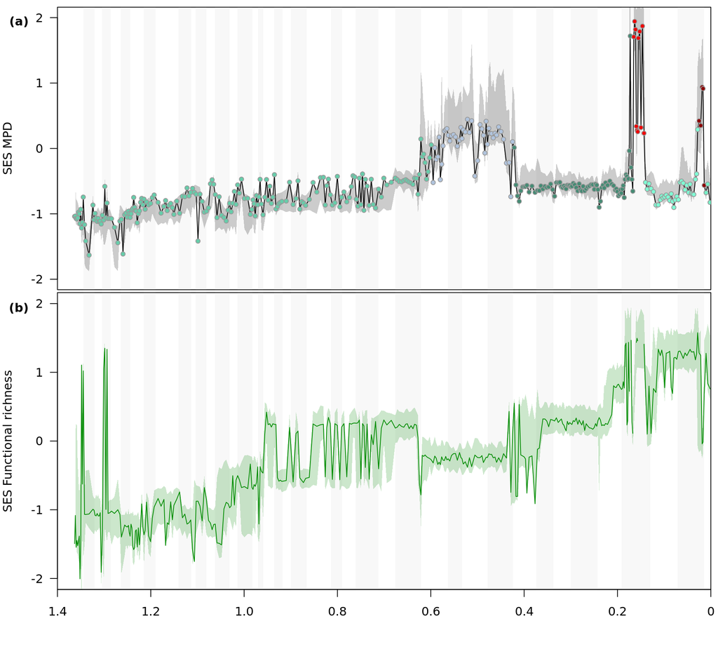

```r
AgeShifts <- brms:::inv_logit(cumDiff(fixef(FitMpd)[13:8, 1])) * -1364.7 # Inferred ages of shifts
AgeShifts <- rev(AgeShifts) # Reorder from most recent to the earliest shift
# Assign colors for periods of distinct MPD (separated by shifts)
ColShift <- rep("grey", length(SesMpd))
ColShift[Comm$Age > AgeShifts[1]] <- "aquamarine2"
ColShift[Comm$Age <= AgeShifts[1] & Comm$Age > AgeShifts[2]] <- "red4"
ColShift[Comm$Age <= AgeShifts[2] & Comm$Age > AgeShifts[3]] <- "aquamarine1"
ColShift[Comm$Age <= AgeShifts[3] & Comm$Age > AgeShifts[4]] <- "red2"
ColShift[Comm$Age <= AgeShifts[4] & Comm$Age > AgeShifts[5]] <- "aquamarine4"
ColShift[Comm$Age <= AgeShifts[5] & Comm$Age > AgeShifts[6]] <- "lightsteelblue"
ColShift[Comm$Age <= AgeShifts[6]] <- "aquamarine3"

layout(matrix(1:2, nrow = 2), heights = c(0.45, 0.55))
par(las = 1, mar = c(0.1, 4, 0.5, 0.5))
plot(Comm$Age, SesMpd, type = "n", xlim = c(-1400, 0), ylim = c(-2, 2),
     xlab = "Time (Ma)", ylab = "SES MPD",
     xaxs = "i", xaxt = "n") # Empty canvas
mtext(text = "(a)", side = 2, line = 2.0, at = par("usr")[4] - diff(par("usr")[3:4]) * 0.05,
      font = 2, cex = 1.0)
plotLR04(LR04, Comm$Age) # Glacial/interglacials
lines(Comm$Age, SesMpd)
polygon(c(SesMpdCI[1, ], rev(SesMpdCI[1, ])),
        c(SesMpdCI[2, ], rev(SesMpdCI[3, ])),
          border = NA, col = adjustcolor("black", 0.2))
points(Comm$Age[-1], SesMpd[-1],
       bg = ColShift[-1], col = "grey60", pch = 21, cex = 0.8)

par(las = 1, mar = c(4, 4, 0.1, 0.5))
plot(Comm$Age, SesFric, type = "n", xlim = c(-1400, 0), ylim = c(-2, 2),
     xlab = "", ylab = "SES Functional richness",
     xaxs = "i", xaxt = "n")
mtext(text = "(b)", side = 2, line = 2.0, at = par("usr")[4] - diff(par("usr")[3:4]) * 0.05,
      font = 2, cex = 1.0)
plotLR04(LR04, Comm$Age) # Glacial/interglacials
polygon(c(SesFricCI[1, ], rev(SesFricCI[1, ])),
        c(SesFricCI[2, ], rev(SesFricCI[3, ])),
          border = NA, col = adjustcolor("green4", 0.2))
lines(Comm$Age, SesFric, col = "green4")
axis(side = 1, at = seq(-1400, 0, 200),
     labels = rev(c("0", "0.2", "0.4", "0.6", "0.8", "1.0", "1.2", "1.4")))
```

**FIGURE 4** Phylogenetic community structure and functional richness in Lake Ohrid over time. (a) Phylogenetic community structure among *Cyclotella* sensu lato species; greenish dots showing distinct periods of environmental filtering, reddish dots phases of species interaction, and blue dots phase of random assembly. The shaded polygon indicates the effect of taxon sampling. (b) Green curve shows the accumulation of functional richness, indicating small (< 0) or large (> 0) occupancy of niche space. The shaded polygon displays the 95% range for a rarefied taxon sampling. Vertical grey and white bars indicate glacial and interglacial periods, respectively.

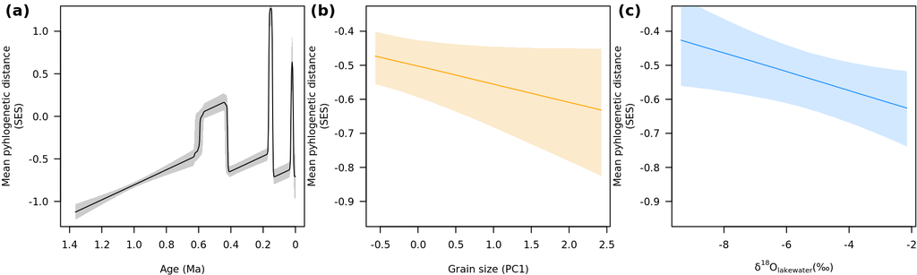

```r
# Get conditional effects from FitMpd object for the age, grainsize and isotopes in 400 equally spaced steps
# along their gradients.
CondEffGs <- brms::conditional_effects(FitMpd, effects = "Grainsize", resolution = 400)
CondEffIso <- brms::conditional_effects(FitMpd, effects = "Iso", resolution = 400)
CondEffAge <- conditional_effects_forked(FitMpd, effects = "Age",
                                         same_as_effects = "AgeScaled", resolution = 400)

layout(matrix(1:3, ncol = 3))
par(las = 1, mar = c(4, 5, 0.5, 0.1))
# Convert rescaled predictor back to original scale
CondEffAge[[1]]$Age <- CondEffAge[[1]]$Age * (1364.7 / -3.242474)
plot(0, 0, type = "n", xlim = c(-1400, 0), ylim = c(-1.2, 1.2), xaxt = "n",
     xlab = "Age (Ma)", ylab = "Mean pyhlogenetic distance\n(SES)")
axis(side = 1, at = seq(-1400, 0, 200),
     labels = rev(c("0", "0.2", "0.4", "0.6", "0.8", "1.0", "1.2", "1.4")))
mtext(text = "(a)", side = 2, line = 2.5,
      at = par("usr")[4] - diff(par("usr")[3:4]) * 0.02, font = 2, cex = 1.0)
polygon(c(CondEffAge[[1]]$Age, rev(CondEffAge[[1]]$Age)),
        c(CondEffAge[[1]]$lower__, rev(CondEffAge[[1]]$upper__)),
        border = NA, col = adjustcolor("black", 0.2))
lines(CondEffAge[[1]]$Age, CondEffAge[[1]]$estimate__, col = "black")

# Convert rescaled predictor back to original scale
CondEffGs$Grainsize$Grainsize <- CondEffGs$Grainsize$Grainsize * DataRegrSd["Grainsize"] + DataRegrMean["Grainsize"]
plot(1, -0.6, type = "n", xlim = range(CondEffGs$Grainsize$Grainsize), ylim = c(-0.95, -0.35),
     xlab = "Grain size (PC1)", ylab = "Mean pyhlogenetic distance\n(SES)")
mtext(text = "(b)", side = 2, line = 2.5,
      at = par("usr")[4] - diff(par("usr")[3:4]) * 0.02, font = 2, cex = 1.0)
polygon(c(CondEffGs$Grainsize$Grainsize, rev(CondEffGs$Grainsize$Grainsize)),
        c(CondEffGs$Grainsize$lower__, rev(CondEffGs$Grainsize$upper__)),
        border = NA, col = adjustcolor("orange2", 0.2))
lines(CondEffGs$Grainsize$Grainsize, CondEffGs$Grainsize$estimate__, col = "orange")

# Convert rescaled predictor back to original scale
CondEffIso$Iso$Iso <- CondEffIso$Iso$Iso * DataRegrSd["Iso"] + DataRegrMean["Iso"]
plot(-8, -0.6, type = "n", xlim = range(CondEffIso$Iso$Iso), ylim = c(-0.95, -0.35),
     xlab = expression(paste(delta^{18}, "O"[lakewater], "(\u2030)")),
     ylab = "Mean pyhlogenetic distance\n(SES)")
mtext(text = "(c)", side = 2, line = 2.5,
      at = par("usr")[4] - diff(par("usr")[3:4]) * 0.02, font = 2, cex = 1.0)
polygon(c(CondEffIso$Iso$Iso, rev(CondEffIso$Iso$Iso)),
        c(CondEffIso$Iso$lower__, rev(CondEffIso$Iso$upper__)),
        border = NA, col = adjustcolor("dodgerblue", 0.2))
lines(CondEffIso$Iso$Iso, CondEffIso$Iso$estimate__, col = "dodgerblue")
```

### Effect of prior choice on the posterior distribution

In general, we specified diffuse to weakly informative priors because completely flat priors (i.e. uniform) preclude convergence of the MPD regression. To demonstrate the minor influence of the priors, we plot the obtained posterior distribution of the regression parameters (i.e. for the effect of time and environmental predictors, magnitude of the shift in MPD and the age of the shifts) and the prior values of the respective parameter that has been used in the analysis. This means we do not plot the prior distribution as it is defined by its parameters (e.g. the mean and variance) but the actual values drawn in the analysis. We have used the argument sample_prior = TRUE of the brm() function to obtain the prior values.

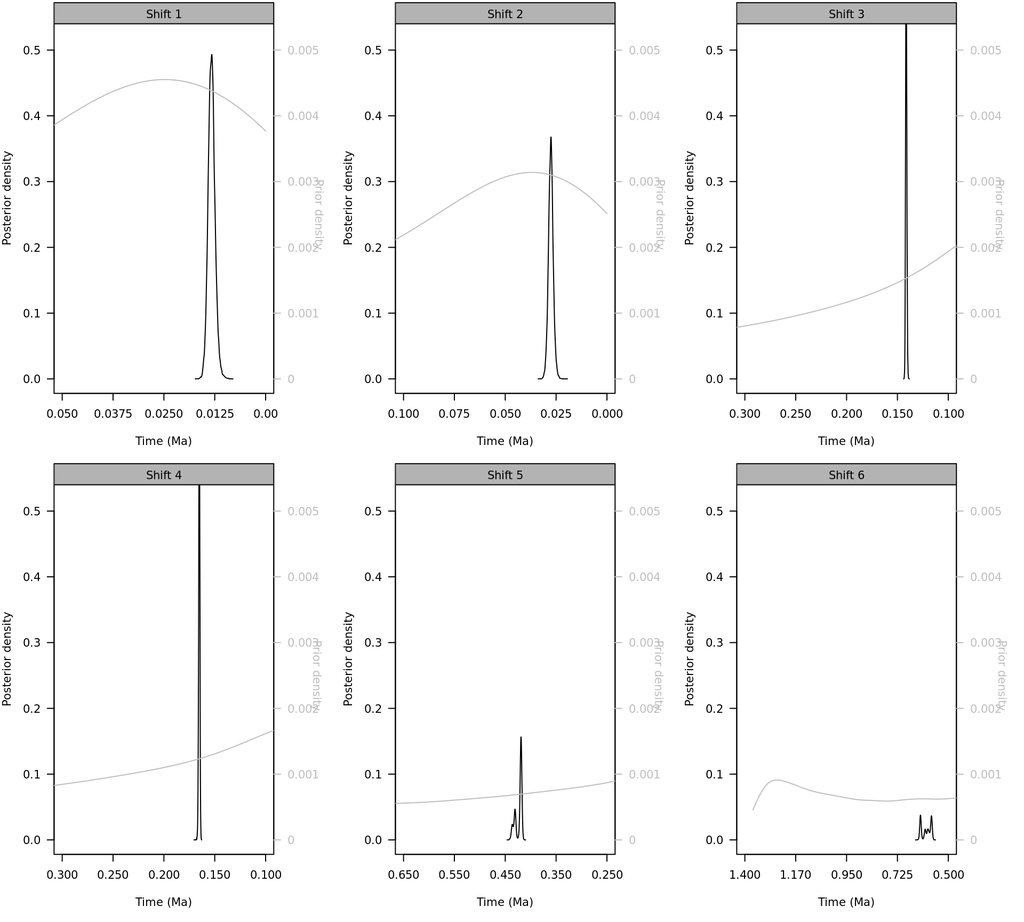

```r
# Get prior draws from the regression analysis
FitMpdPriorDraws<- prior_draws(FitMpd)
S1PD <- FitMpdPriorDraws$b_S1 # Prior draws for ages of shift 1
S2PD <- FitMpdPriorDraws$b_S2
S3PD <- FitMpdPriorDraws$b_S3
S4PD <- FitMpdPriorDraws$b_S4
S5PD <- FitMpdPriorDraws$b_S5
S6PD <- FitMpdPriorDraws$b_S6
S6PDtrans <- brms:::inv_logit(S6PD) * -1364.7 # Inverse logit transformation to values on a scale [0, 1364 ka]
S5PDtrans <- brms:::inv_logit(S6PD - S5PD) * -1364.7 # Age of second oldest shift is shift 6 - parameter for shift 5
S4PDtrans <- brms:::inv_logit(S6PD - S5PD - S4PD) * -1364.7
S3PDtrans <- brms:::inv_logit(S6PD - S5PD - S4PD - S3PD) * -1364.7
S2PDtrans <- brms:::inv_logit(S6PD - S5PD - S4PD - S3PD - S2PD) * -1364.7
S1PDtrans <- brms:::inv_logit(S6PD - S5PD - S4PD - S3PD - S2PD - S1PD) * -1364.7

layout(matrix(1:6, nrow = 2, ncol = 3, byrow = TRUE)) # Canvas of 2x3 panels
par(las = 1, mar = c(5, 4, 0.2, 5)) # Define label orientation and plot margins

DenPrior <- density(S1PDtrans, from = -1364.7, to = 0, n = 2024) # Get prior density
DenPost <- density(S1trans) # Get posterior density
plot(DenPost$x, DenPost$y, type = "l", ylim = c(0, 0.55), xlim = c(-50, 0),
     xlab = "Time (Ma)", ylab = "Posterior density", xaxt = "n") # Plot posterior density
axis(side = 4, at = seq(0, 0.5, length.out = 6), label = seq(0, 0.005, length.out = 6),
     col.ticks = "grey", col.axis = "grey") # Add ticks to the right axis
axis(side = 1, at = seq(-50, 0, length.out = 5),
     labels = c("0.050", "0.0375", "0.0250", "0.0125", "0.00")) # Add tick-labels to the x-axis
text(x = par("usr")[2] + 11, y = 0.25, labels = "Prior density", col = "grey",
     xpd = TRUE, srt = -90) # Add label to the axis on the right
lines(DenPrior$x, DenPrior$y * 100, col = "grey") # Draw line for prior density
rect(xleft = par("usr")[1], ybottom = 0.54, xright = par("usr")[2], ytop = par("usr")[4],
       col = "grey70", border = "black") # Draw grey rectangle as background for the plot title
text(x = -25, y = 0.555, labels = "Shift 1", adj = c(0.5, 0.5)) # Plot title

# Now we create the same style of plots but with a custom function
# because we will need to plot prior/posteriors another 20 times
plotPriorVerusPosterior(Prior = S2PDtrans, Post = S2trans,
                        DensFrom = -1364.7, DensTo = 0, DensN = 2024,
                        Xlim = c(-100, 0), Ylim = c(0, 0.55),
                        Xlab = "Time (Ma)", ColPrior = "grey",
                        YTicks = seq(0, 0.5, length.out = 6),
                        PriorTickLabels = seq(0, 0.005, length.out = 6),
                        PriorMulti = 100,
                        Xticks = seq(-100, 0, length.out = 5),
                        XticksLabels = c("0.100", "0.075", "0.050", "0.025", "0.000"),
                        LabAxis4X = 22, LabAxis4Y = 0.25,
                        TitleBarY = 0.54, TitleX = -50, TitleY = 0.555, Title = "Shift 2")

plotPriorVerusPosterior(Prior = S3PDtrans, Post = S3trans,
                        DensFrom = -1364.7, DensTo = 0, DensN = 2024,
                        Xlim = c(-300, -100), Ylim = c(0, 0.55),
                        Xlab = "Time (Ma)", ColPrior = "grey",
                        YTicks = seq(0, 0.5, length.out = 6),
                        PriorTickLabels = seq(0, 0.005, length.out = 6),
                        PriorMulti = 100,
                        Xticks = seq(-300, -100, length.out = 5),
                        XticksLabels = c("0.300", "0.250", "0.200", "0.150", "0.100"),
                        LabAxis4X = 42, LabAxis4Y = 0.25,
                        TitleBarY = 0.54, TitleX = -200, TitleY = 0.555, Title = "Shift 3")

plotPriorVerusPosterior(Prior = S4PDtrans, Post = S4trans,
                        DensFrom = -1364.7, DensTo = 0, DensN = 2024,
                        Xlim = c(-300, -100), Ylim = c(0, 0.55),
                        Xlab = "Time (Ma)", ColPrior = "grey",
                        YTicks = seq(0, 0.5, length.out = 6),
                        PriorTickLabels = seq(0, 0.005, length.out = 6),
                        PriorMulti = 100,
                        Xticks = seq(-300, -100, length.out = 5),
                        XticksLabels = c("0.300", "0.250", "0.200", "0.150", "0.100"),
                        LabAxis4X = 42, LabAxis4Y = 0.25,
                        TitleBarY = 0.54, TitleX = -200, TitleY = 0.555, Title = "Shift 4")

plotPriorVerusPosterior(Prior = S5PDtrans, Post = S5trans,
                        DensFrom = -1364.7, DensTo = 0, DensN = 2024,
                        Xlim = c(-650, -250), Ylim = c(0, 0.55),
                        Xlab = "Time (Ma)", ColPrior = "grey",
                        YTicks = seq(0, 0.5, length.out = 6),
                        PriorTickLabels = seq(0, 0.005, length.out = 6),
                        PriorMulti = 100,
                        Xticks = seq(-650, -250, length.out = 5),
                        XticksLabels = c("0.650", "0.550", "0.450", "0.350", "0.250"),
                        LabAxis4X = 85, LabAxis4Y = 0.25,
                        TitleBarY = 0.54, TitleX = -450, TitleY = 0.555, Title = "Shift 5")

plotPriorVerusPosterior(Prior = S6PDtrans, Post = S6trans,
                        DensFrom = -1364.7, DensTo = 0, DensN = 2024,
                        Xlim = c(-1400, -500), Ylim = c(0, 0.55),
                        Xlab = "Time (Ma)", ColPrior = "grey",
                        YTicks = seq(0, 0.5, length.out = 6),
                        PriorTickLabels = seq(0, 0.005, length.out = 6),
                        PriorMulti = 100,
                        Xticks = seq(-1400, -500, length.out = 5),
                        XticksLabels = c("1.400", "1.170", "0.950", "0.725", "0.500"),
                        LabAxis4X = 200, LabAxis4Y = 0.25,
                        TitleBarY = 0.54, TitleX = -950, TitleY = 0.555, Title = "Shift 6")
```

**Figure S3** Comparing prior and posterior distribution of the ages of discrete shifts in mean phylogenetic distance of *Cyclotella* sensu lato assemblages in Lake Ohrid. Black lines show the sampled parameters for the ages of the shifts and grey lines the prior values for the ages, which we logged during the sampling phase of the Bayesian inference. All posterior and prior values were transformed after the analysis to our time frame of 1.36 Ma because for all shifts except the earliest one, the parameters are specified in the analysis to be the time difference between two consecutive shifts. This model specification constrained shift $S_{k-1}$ to be more recent then shift $S_{k}$.

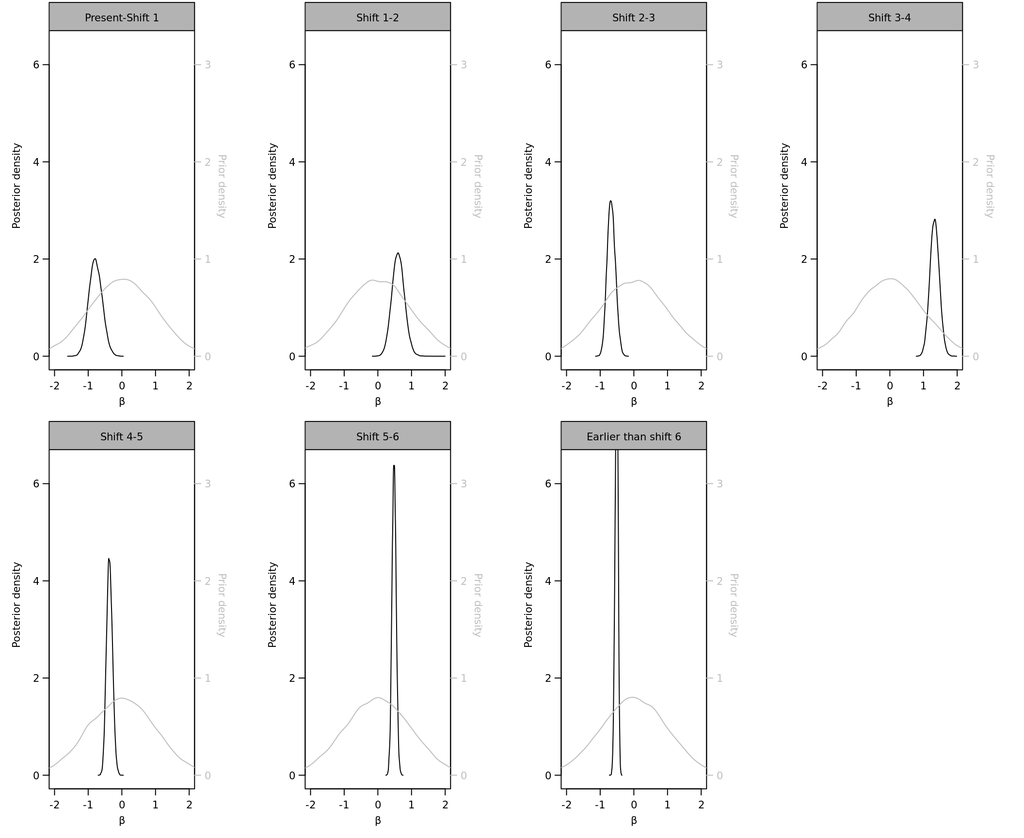

```r
bS1PD <- FitMpdPriorDraws$b_bS1 # Prior draws for the effect of shift 1 (i.e. MPD from Shift 1 until the present)
bS2PD <- FitMpdPriorDraws$b_bS2 # Prior draws for the effect of shift 2 (i.e. MPD from Shift 2 until Shift 1)
bS3PD <- FitMpdPriorDraws$b_bS3
bS4PD <- FitMpdPriorDraws$b_bS4
bS5PD <- FitMpdPriorDraws$b_bS5
bS6PD <- FitMpdPriorDraws$b_bS6
# Prior draws for the intercept of the model, which is the MPD from 1.36 Ma until Shift 6
# when the predictor age, paleoenvironment and climate are equal to zero)
bS7PD <- FitMpdPriorDraws$b_bS7

# Posterior draws for the effect of shift 1 (i.e. MPD from Shift 1 until the present)
bS1 <- FitMpdDraws$nlpars$bS1$fe$b[, 1]
# Posterior draws for the effect of shift 2 (i.e. MPD from Shift 2 until Shift 1)
bS2 <- FitMpdDraws$nlpars$bS2$fe$b[, 1]
bS3 <- FitMpdDraws$nlpars$bS3$fe$b[, 1]
bS4 <- FitMpdDraws$nlpars$bS4$fe$b[, 1]
bS5 <- FitMpdDraws$nlpars$bS5$fe$b[, 1]
bS6 <- FitMpdDraws$nlpars$bS6$fe$b[, 1]
# Posterior draws for the intercept of the model, which is the MPD from 1.36 Ma until Shift 6
# when the predictor age, paleoenvironment and climate are equal to zero)
bS7 <- FitMpdDraws$nlpars$bS7$fe$b[, 1]

layout(matrix(1:8, nrow = 2, ncol = 4, byrow = TRUE)) # Canvas of 2x3 panels
# Define label orientation, plot margins and distance of axis labels
par(las = 1, mar = c(4, 4, 0.2, 5), mgp = c(2.2, 0.8, 0))

plotPriorVerusPosterior(Prior = bS1PD, Post = bS1,
                        DensFrom = -3, DensTo = 3, DensN = 2024,
                        Xlim = c(-2, 2), Ylim = c(0, 7),
                        Xlab = expression(beta), ColPrior = "grey",
                        YTicks = seq(0, 6, length.out = 4),
                        PriorTickLabels = seq(0, 3, length.out = 4),
                        PriorMulti = 4,
                        Xticks = seq(-2, 2, length.out = 5),
                        XticksLabels = c("-2", "-1", "0", "1", "2"),
                        LabAxis4X = 0.8, LabAxis4Y = 3.5,
                        TitleBarY = 6.7, TitleX = 0, TitleY = 6.97, Title = "Present-Shift 1")

plotPriorVerusPosterior(Prior = bS2PD, Post = bS2,
                        DensFrom = -3, DensTo = 3, DensN = 2024,
                        Xlim = c(-2, 2), Ylim = c(0, 7),
                        Xlab = expression(beta), ColPrior = "grey",
                        YTicks = seq(0, 6, length.out = 4),
                        PriorTickLabels = seq(0, 3, length.out = 4),
                        PriorMulti = 4,
                        Xticks = seq(-2, 2, length.out = 5),
                        XticksLabels = c("-2", "-1", "0", "1", "2"),
                        LabAxis4X = 0.8, LabAxis4Y = 3.5,
                        TitleBarY = 6.7, TitleX = 0, TitleY = 6.97, Title = "Shift 1-2")

plotPriorVerusPosterior(Prior = bS3PD, Post = bS3,
                        DensFrom = -3, DensTo = 3, DensN = 2024,
                        Xlim = c(-2, 2), Ylim = c(0, 7),
                        Xlab = expression(beta), ColPrior = "grey",
                        YTicks = seq(0, 6, length.out = 4),
                        PriorTickLabels = seq(0, 3, length.out = 4),
                        PriorMulti = 4,
                        Xticks = seq(-2, 2, length.out = 5),
                        XticksLabels = c("-2", "-1", "0", "1", "2"),
                        LabAxis4X = 0.8, LabAxis4Y = 3.5,
                        TitleBarY = 6.7, TitleX = 0, TitleY = 6.97, Title = "Shift 2-3")

plotPriorVerusPosterior(Prior = bS4PD, Post = bS4,
                        DensFrom = -3, DensTo = 3, DensN = 2024,
                        Xlim = c(-2, 2), Ylim = c(0, 7),
                        Xlab = expression(beta), ColPrior = "grey",
                        YTicks = seq(0, 6, length.out = 4),
                        PriorTickLabels = seq(0, 3, length.out = 4),
                        PriorMulti = 4,
                        Xticks = seq(-2, 2, length.out = 5),
                        XticksLabels = c("-2", "-1", "0", "1", "2"),
                        LabAxis4X = 0.8, LabAxis4Y = 3.5,
                        TitleBarY = 6.7, TitleX = 0, TitleY = 6.97, Title = "Shift 3-4")

plotPriorVerusPosterior(Prior = bS5PD, Post = bS5,
                        DensFrom = -3, DensTo = 3, DensN = 2024,
                        Xlim = c(-2, 2), Ylim = c(0, 7),
                        Xlab = expression(beta), ColPrior = "grey",
                        YTicks = seq(0, 6, length.out = 4),
                        PriorTickLabels = seq(0, 3, length.out = 4),
                        PriorMulti = 4,
                        Xticks = seq(-2, 2, length.out = 5),
                        XticksLabels = c("-2", "-1", "0", "1", "2"),
                        LabAxis4X = 0.8, LabAxis4Y = 3.5,
                        TitleBarY = 6.7, TitleX = 0, TitleY = 6.97, Title = "Shift 4-5")

plotPriorVerusPosterior(Prior = bS6PD, Post = bS6,
                        DensFrom = -3, DensTo = 3, DensN = 2024,
                        Xlim = c(-2, 2), Ylim = c(0, 7),
                        Xlab = expression(beta), ColPrior = "grey",
                        YTicks = seq(0, 6, length.out = 4),
                        PriorTickLabels = seq(0, 3, length.out = 4),
                        PriorMulti = 4,
                        Xticks = seq(-2, 2, length.out = 5),
                        XticksLabels = c("-2", "-1", "0", "1", "2"),
                        LabAxis4X = 0.8, LabAxis4Y = 3.5,
                        TitleBarY = 6.7, TitleX = 0, TitleY = 6.97, Title = "Shift 5-6")

plotPriorVerusPosterior(Prior = bS7PD, Post = bS7,
                        DensFrom = -3, DensTo = 3, DensN = 2024,
                        Xlim = c(-2, 2), Ylim = c(0, 7),
                        Xlab = expression(beta), ColPrior = "grey",
                        YTicks = seq(0, 6, length.out = 4),
                        PriorTickLabels = seq(0, 3, length.out = 4),
                        PriorMulti = 4,
                        Xticks = seq(-2, 2, length.out = 5),
                        XticksLabels = c("-2", "-1", "0", "1", "2"),
                        LabAxis4X = 0.8, LabAxis4Y = 3.5,
                        TitleBarY = 6.7, TitleX = 0, TitleY = 6.97, Title = "Earlier than shift 6")
```

**Figure S4** Comparing prior and posterior distribution of the effects of discrete shifts on mean phylogenetic distance of Lake Ohrid *Cyclotella* sensu lato assemblages. Black lines show the sampled parameters for the offset in MPD caused at the age of a shift in comparison to the value of MPD between 1.36 Ma and the earliest shift (i.e. Shift 6). Grey lines indicate the prior values for these parameters, which we logged during the sampling phase of the Bayesian inference.

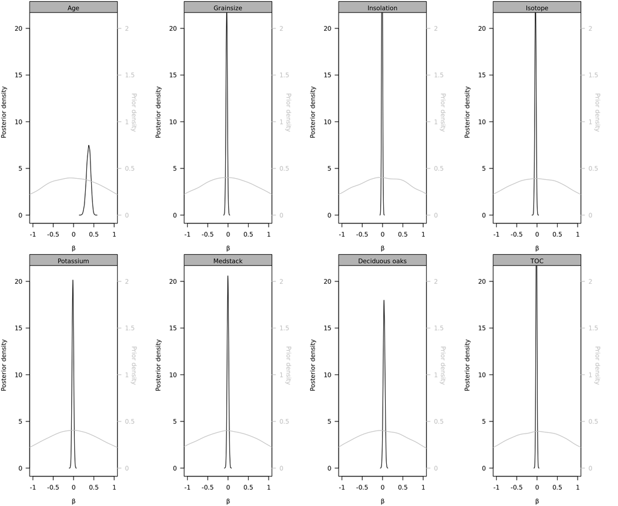

```r
bAgePD <- FitMpdPriorDraws$b_bAge # Prior draws for the effect of age on MPD
bGrainPD <- FitMpdPriorDraws$b_bGrain
bInsPD <- FitMpdPriorDraws$b_bIns
bIsoPD <- FitMpdPriorDraws$b_bIso
bKPD <- FitMpdPriorDraws$b_bK
bMedPD <- FitMpdPriorDraws$b_bMed
bOaksPD <- FitMpdPriorDraws$b_bOaks
bTocPD <- FitMpdPriorDraws$b_bToc

bAge <- FitMpdDraws$nlpars$bAge$fe$b[, 1] # Posterior draws for the effect of age on MPD
bGrain <- FitMpdDraws$nlpars$bGrain$fe$b[, 1]
bIns <- FitMpdDraws$nlpars$bIns$fe$b[, 1]
bIso <- FitMpdDraws$nlpars$bIso$fe$b[, 1]
bK <- FitMpdDraws$nlpars$bK$fe$b[, 1]
bMed <- FitMpdDraws$nlpars$bMed$fe$b[, 1]
bOaks <- FitMpdDraws$nlpars$bOaks$fe$b[, 1]
bToc <- FitMpdDraws$nlpars$bToc$fe$b[, 1]

layout(matrix(1:8, nrow = 2, ncol = 4, byrow = TRUE)) # Canvas of 2x3 panels
par(las = 1, mar = c(4, 4, 0.2, 5)) # Define label orientation and plot margins

plotPriorVerusPosterior(Prior = bAgePD, Post = bAge,
                        DensFrom = -2, DensTo = 2, DensN = 2024,
                        Xlim = c(-1, 1), Ylim = c(0, 22),
                        Xlab = expression(beta), ColPrior = "grey",
                        YTicks = seq(0, 20, length.out = 5),
                        PriorTickLabels = seq(0, 2, length.out = 5),
                        PriorMulti = 10,
                        Xticks = seq(-1, 1, length.out = 5),
                        XticksLabels = c("-1", "-0.5", "0", "0.5", "1"),
                        LabAxis4X = 0.4, LabAxis4Y = 11,
                        TitleBarY = 21.7, TitleX = 0, TitleY = 22.2, Title = "Age")

plotPriorVerusPosterior(Prior = bGrainPD, Post = bGrain,
                        DensFrom = -2, DensTo = 2, DensN = 2024,
                        Xlim = c(-1, 1), Ylim = c(0, 22),
                        Xlab = expression(beta), ColPrior = "grey",
                        YTicks = seq(0, 20, length.out = 5),
                        PriorTickLabels = seq(0, 2, length.out = 5),
                        PriorMulti = 10,
                        Xticks = seq(-1, 1, length.out = 5),
                        XticksLabels = c("-1", "-0.5", "0", "0.5", "1"),
                        LabAxis4X = 0.4, LabAxis4Y = 11,
                        TitleBarY = 21.7, TitleX = 0, TitleY = 22.2, Title = "Grainsize")

plotPriorVerusPosterior(Prior = bInsPD, Post = bIns,
                        DensFrom = -2, DensTo = 2, DensN = 2024,
                        Xlim = c(-1, 1), Ylim = c(0, 22),
                        Xlab = expression(beta), ColPrior = "grey",
                        YTicks = seq(0, 20, length.out = 5),
                        PriorTickLabels = seq(0, 2, length.out = 5),
                        PriorMulti = 10,
                        Xticks = seq(-1, 1, length.out = 5),
                        XticksLabels = c("-1", "-0.5", "0", "0.5", "1"),
                        LabAxis4X = 0.4, LabAxis4Y = 11,
                        TitleBarY = 21.7, TitleX = 0, TitleY = 22.2, Title = "Insolation")

plotPriorVerusPosterior(Prior = bIsoPD, Post = bIso,
                        DensFrom = -2, DensTo = 2, DensN = 2024,
                        Xlim = c(-1, 1), Ylim = c(0, 22),
                        Xlab = expression(beta), ColPrior = "grey",
                        YTicks = seq(0, 20, length.out = 5),
                        PriorTickLabels = seq(0, 2, length.out = 5),
                        PriorMulti = 10,
                        Xticks = seq(-1, 1, length.out = 5),
                        XticksLabels = c("-1", "-0.5", "0", "0.5", "1"),
                        LabAxis4X = 0.4, LabAxis4Y = 11,
                        TitleBarY = 21.7, TitleX = 0, TitleY = 22.2, Title = "Isotope")

plotPriorVerusPosterior(Prior = bKPD, Post = bK,
                        DensFrom = -2, DensTo = 2, DensN = 2024,
                        Xlim = c(-1, 1), Ylim = c(0, 22),
                        Xlab = expression(beta), ColPrior = "grey",
                        YTicks = seq(0, 20, length.out = 5),
                        PriorTickLabels = seq(0, 2, length.out = 5),
                        PriorMulti = 10,
                        Xticks = seq(-1, 1, length.out = 5),
                        XticksLabels = c("-1", "-0.5", "0", "0.5", "1"),
                        LabAxis4X = 0.4, LabAxis4Y = 11,
                        TitleBarY = 21.7, TitleX = 0, TitleY = 22.2, Title = "Potassium")

plotPriorVerusPosterior(Prior = bMedPD, Post = bMed,
                        DensFrom = -2, DensTo = 2, DensN = 2024,
                        Xlim = c(-1, 1), Ylim = c(0, 22),
                        Xlab = expression(beta), ColPrior = "grey",
                        YTicks = seq(0, 20, length.out = 5),
                        PriorTickLabels = seq(0, 2, length.out = 5),
                        PriorMulti = 10,
                        Xticks = seq(-1, 1, length.out = 5),
                        XticksLabels = c("-1", "-0.5", "0", "0.5", "1"),
                        LabAxis4X = 0.4, LabAxis4Y = 11,
                        TitleBarY = 21.7, TitleX = 0, TitleY = 22.2, Title = "Medstack")

plotPriorVerusPosterior(Prior = bOaksPD, Post = bOaks,
                        DensFrom = -2, DensTo = 2, DensN = 2024,
                        Xlim = c(-1, 1), Ylim = c(0, 22),
                        Xlab = expression(beta), ColPrior = "grey",
                        YTicks = seq(0, 20, length.out = 5),
                        PriorTickLabels = seq(0, 2, length.out = 5),
                        PriorMulti = 10,
                        Xticks = seq(-1, 1, length.out = 5),
                        XticksLabels = c("-1", "-0.5", "0", "0.5", "1"),
                        LabAxis4X = 0.4, LabAxis4Y = 11,
                        TitleBarY = 21.7, TitleX = 0, TitleY = 22.2, Title = "Deciduous oaks")

plotPriorVerusPosterior(Prior = bTocPD, Post = bToc,
                        DensFrom = -2, DensTo = 2, DensN = 2024,
                        Xlim = c(-1, 1), Ylim = c(0, 22),
                        Xlab = expression(beta), ColPrior = "grey",
                        YTicks = seq(0, 20, length.out = 5),
                        PriorTickLabels = seq(0, 2, length.out = 5),
                        PriorMulti = 10,
                        Xticks = seq(-1, 1, length.out = 5),
                        XticksLabels = c("-1", "-0.5", "0", "0.5", "1"),
                        LabAxis4X = 0.4, LabAxis4Y = 11,
                        TitleBarY = 21.7, TitleX = 0, TitleY = 22.2, Title = "TOC")
```

**Figure S5** Comparing prior and posterior distribution of the effects of discrete shifts on mean phylogenetic distance of Lake Ohrid *Cyclotella* sensu lato assemblages. Black lines show the sampled parameters for the effect of local paleoenvironmental, climatic, and intrinsic biological predictors on MPD. Grey lines indicate the prior values for these parameters, which were logged during the sampling phase of the Bayesian inference.